# Estimating Value-at-Risk of a Portfolio with GARCH-family Models

### ARMA(7,7)-GARCH(2,1)

```r
arma77garch21 <- fit_garch(insample_r$r, 7, 7, 2, 1)
arma77garch21
```

```
##
## *---------------------------------*
## *          GARCH Model Fit        *
## *---------------------------------*
##
## Conditional Variance Dynamics
## -----------------------------------
## GARCH Model  : sGARCH(2,1)
## Mean Model   : ARFIMA(7,0,7)
## Distribution : norm
##
## Optimal Parameters
## ------------------------------------
##         Estimate  Std. Error   t value Pr(>|t|)
## mu      0.001174    0.000478   2.45351 0.014147
## ar1    -0.480630    0.110443  -4.35183 0.000014
## ar2    -0.188292    0.031420  -5.99267 0.000000
## ar3    -0.029737    0.078466  -0.37898 0.704703
## ar4     0.039288    0.070961   0.55366 0.579813
## ar5    -0.541569    0.071492  -7.57527 0.000000
## ar6    -0.829261    0.025059 -33.09242 0.000000
## ar7    -0.228938    0.088590  -2.58425 0.009759
## ma1     0.523866    0.102412   5.11527 0.000000
## ma2     0.252641    0.020948  12.06041 0.000000
## ma3     0.011364    0.078397   0.14496 0.884746
## ma4    -0.034677    0.074522  -0.46532 0.641700
## ma5     0.535675    0.073508   7.28728 0.000000
## ma6     0.836850    0.002093 399.90864 0.000000
## ma7     0.345888    0.085018   4.06841 0.000047
## omega   0.000020    0.000007   2.67405 0.007494
## alpha1  0.073487    0.038562   1.90570 0.056689
## alpha2  0.054337    0.053476   1.01610 0.309580
## beta1   0.796205    0.056149  14.18028 0.000000
##
## Robust Standard Errors:
##         Estimate  Std. Error   t value Pr(>|t|)
## mu      0.001174    0.000504   2.33111 0.019748
## ar1    -0.480630    0.113715  -4.22661 0.000024
## ar2    -0.188292    0.034346  -5.48225 0.000000
## ar3    -0.029737    0.088386  -0.33644 0.736537
```

[output cut: 82 more lines]

```
## Negative Sign Bias  1.9419 0.05243   *
## Positive Sign Bias  1.3643 0.17278
## Joint Effect        8.4204 0.03808  **
##
##
## Adjusted Pearson Goodness-of-Fit Test:
## ------------------------------------
##   group statistic p-value(g-1)
## 1    20     28.99     0.066142
## 2    30     43.97     0.036983
## 3    40     61.02     0.013613
## 4    50     84.06     0.001352
##
##
## Elapsed time : 2.710148
```

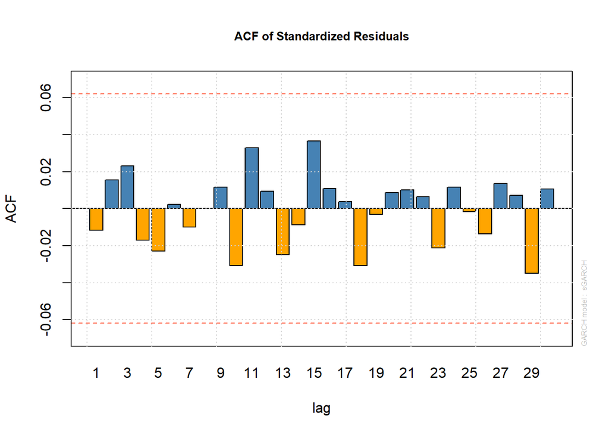

```r
plot_std_residuals(arma77garch21)
```

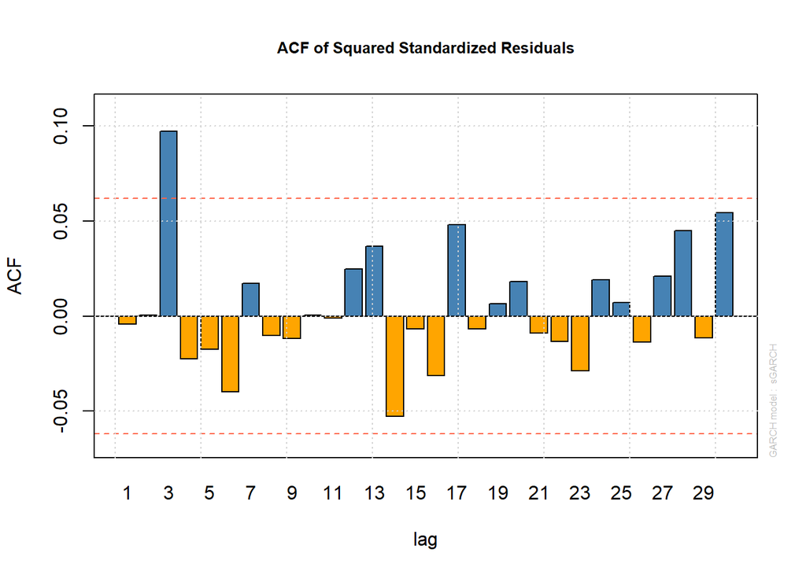

```r
plot_std_sq_residuals(arma77garch21)
```

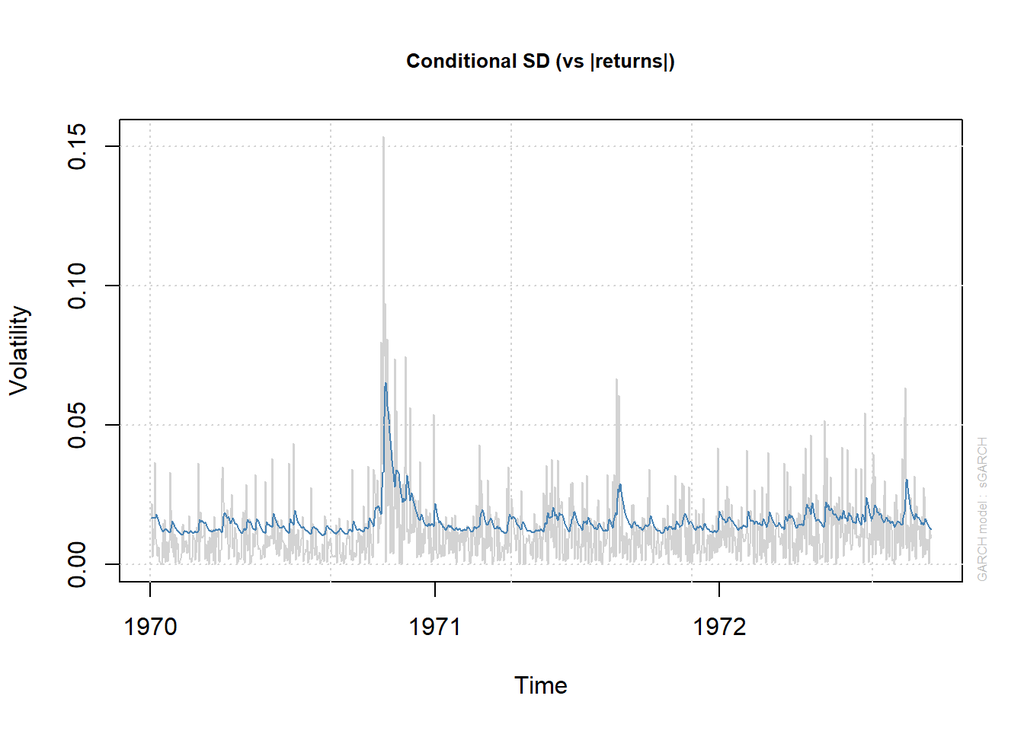

```r
plot_conditional_sd(arma77garch21)
```

#### Comment

- AR(3), AR(4), MA(3), MA(4) lags are insignificant, as well as ARCH(1) and ARCH(2).
- ACF of standardized residuals confidently shows no autocorrelation.
- ACF of squared standardized residuals shows significant third lag, as in all previous cases.
- Both Ljung-Box test for standardized squared residuals and LM tests do not allow us to reject null-hypothesis of no autocorrelation of said residuals.

Let’s try reducing amount of ARMA lags.

### ARMA(5,5)-GARCH(2,1)

```r
arma55garch21 <- fit_garch(insample_r$r, 5, 5, 2, 1)
arma55garch21
```

```
##
## *---------------------------------*
## *          GARCH Model Fit        *
## *---------------------------------*
##
## Conditional Variance Dynamics
## -----------------------------------
## GARCH Model  : sGARCH(2,1)
## Mean Model   : ARFIMA(5,0,5)
## Distribution : norm
##
## Optimal Parameters
## ------------------------------------
##         Estimate  Std. Error   t value Pr(>|t|)
## mu      0.001262    0.000453    2.7881 0.005302
## ar1    -1.917412    0.006307 -304.0314 0.000000
## ar2    -2.197336    0.004142 -530.5073 0.000000
## ar3    -2.184846    0.012768 -171.1202 0.000000
## ar4    -1.551763    0.011193 -138.6380 0.000000
## ar5    -0.482570    0.008353  -57.7746 0.000000
## ma1     1.930644    0.001080 1787.9795 0.000000
## ma2     2.282636    0.000608 3756.5777 0.000000
## ma3     2.307023    0.001337 1726.0139 0.000000
## ma4     1.674864    0.000672 2491.8146 0.000000
## ma5     0.569080    0.000225 2531.5915 0.000000
## omega   0.000018    0.000004    4.2792 0.000019
## alpha1  0.067345    0.034358    1.9601 0.049981
## alpha2  0.058418    0.038741    1.5079 0.131577
## beta1   0.807464    0.030003   26.9125 0.000000
##
## Robust Standard Errors:
##         Estimate  Std. Error   t value Pr(>|t|)
## mu      0.001262    0.000495    2.5497 0.010781
## ar1    -1.917412    0.008079 -237.3433 0.000000
## ar2    -2.197336    0.009256 -237.4068 0.000000
## ar3    -2.184846    0.010107 -216.1694 0.000000
## ar4    -1.551763    0.008522 -182.0802 0.000000
## ar5    -0.482570    0.010538  -45.7929 0.000000
## ma1     1.930644    0.001307 1477.6642 0.000000
## ma2     2.282636    0.000805 2835.4494 0.000000
```

[output cut: 70 more lines]

```
## Negative Sign Bias   2.091 0.03680  **
## Positive Sign Bias   1.552 0.12108
## Joint Effect         7.458 0.05866   *
##
##
## Adjusted Pearson Goodness-of-Fit Test:
## ------------------------------------
##   group statistic p-value(g-1)
## 1    20     32.79      0.02544
## 2    30     42.41      0.05160
## 3    40     61.58      0.01206
## 4    50     72.18      0.01725
##
##
## Elapsed time : 2.138698
```

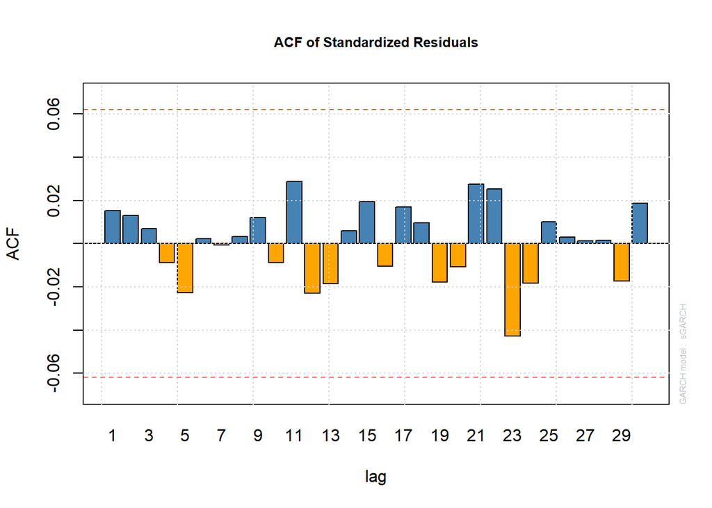

```r
plot_std_residuals(arma55garch21)
```

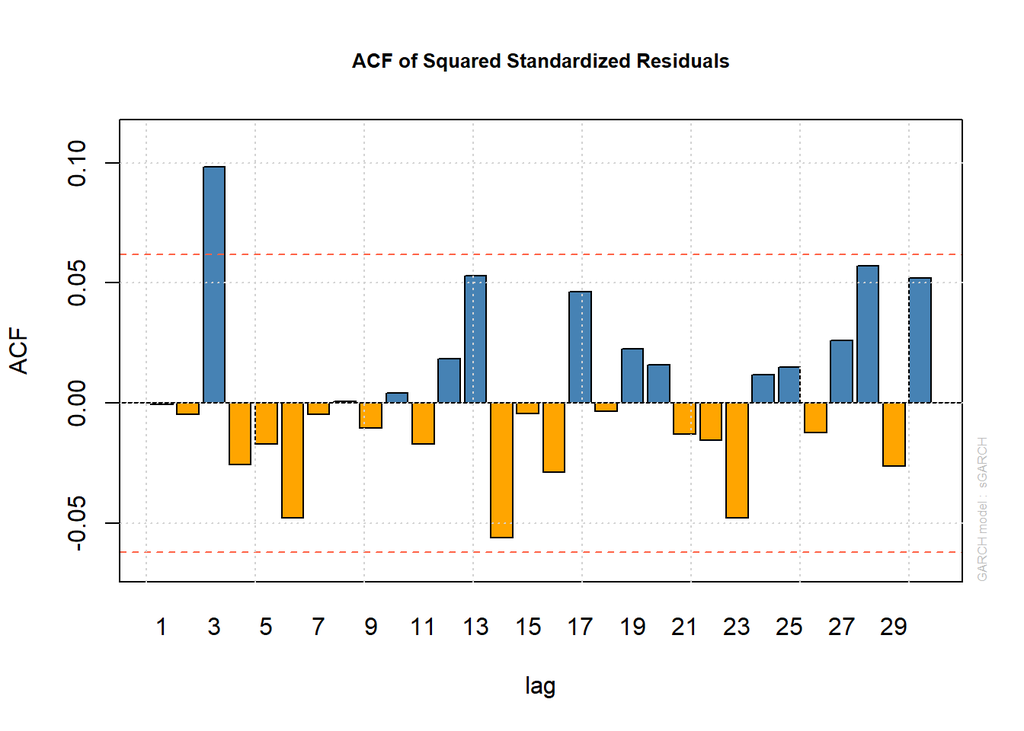

```r
plot_std_sq_residuals(arma55garch21)
```

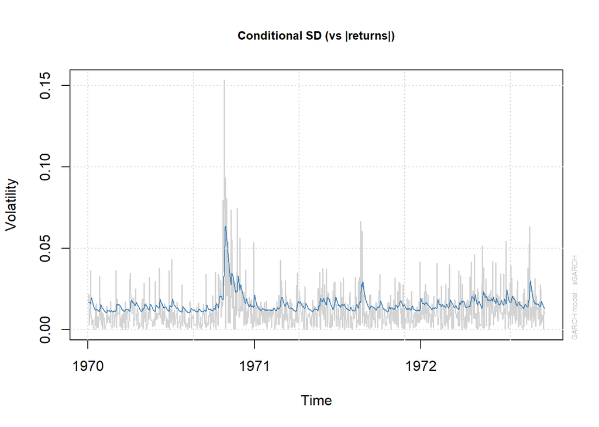

```r
plot_conditional_sd(arma55garch21)
```

#### Comment

- Only ARCH(2) is insignificant.
- ACF of standardized residuals shows no significant lags.
- ACF of squared standardized residuals shows significant third lag, as in all previous cases.
- Both Ljung-Box test for standardized squared residuals and LM tests do not allow us to reject null-hypothesis of no autocorrelation of said residuals.

Let’s try adding more GARCH components.

### ARMA(5,5)-GARCH(2,2)

```r
arma55garch22 <- fit_garch(insample_r$r, 5, 5, 2, 2)
arma55garch22
```

```
##
## *---------------------------------*
## *          GARCH Model Fit        *
## *---------------------------------*
##
## Conditional Variance Dynamics
## -----------------------------------
## GARCH Model  : sGARCH(2,2)
## Mean Model   : ARFIMA(5,0,5)
## Distribution : norm
##
## Optimal Parameters
## ------------------------------------
##         Estimate  Std. Error    t value Pr(>|t|)
## mu      0.001373    0.000042    32.9698 0.000000
## ar1    -0.879464    0.000541 -1626.8345 0.000000
## ar2    -0.767320    0.000542 -1415.1485 0.000000
## ar3    -0.609817    0.000408 -1496.3890 0.000000
## ar4    -0.152568    0.000246  -619.3557 0.000000
## ar5     0.435114    0.000351  1240.9937 0.000000
## ma1     0.865402    0.000211  4100.3204 0.000000
## ma2     0.832258    0.000191  4367.8519 0.000000
## ma3     0.666593    0.000178  3754.4738 0.000000
## ma4     0.197839    0.000076  2595.9073 0.000000
## ma5    -0.444133    0.000126 -3516.5433 0.000000
## omega   0.000022    0.000008     2.5711 0.010137
## alpha1  0.067498    0.034265     1.9699 0.048853
## alpha2  0.077868    0.050529     1.5411 0.123298
## beta1   0.707983    0.279941     2.5290 0.011437
## beta2   0.062281    0.231956     0.2685 0.788313
##
## Robust Standard Errors:
##         Estimate  Std. Error     t value Pr(>|t|)
## mu      0.001373    0.000039    35.16977 0.000000
## ar1    -0.879464    0.000575 -1529.91421 0.000000
## ar2    -0.767320    0.000636 -1206.84122 0.000000
## ar3    -0.609817    0.000843  -723.42592 0.000000
## ar4    -0.152568    0.000414  -368.90536 0.000000
## ar5     0.435114    0.000494   880.50268 0.000000
## ma1     0.865402    0.000771  1122.08194 0.000000
```

[output cut: 73 more lines]

```
## Negative Sign Bias  1.8102 0.07057   *
## Positive Sign Bias  1.2964 0.19514
## Joint Effect        6.6933 0.08234   *
##
##
## Adjusted Pearson Goodness-of-Fit Test:
## ------------------------------------
##   group statistic p-value(g-1)
## 1    20     38.22     0.005562
## 2    30     54.27     0.003008
## 3    40     65.97     0.004450
## 4    50     77.47     0.005880
##
##
## Elapsed time : 2.067432
```

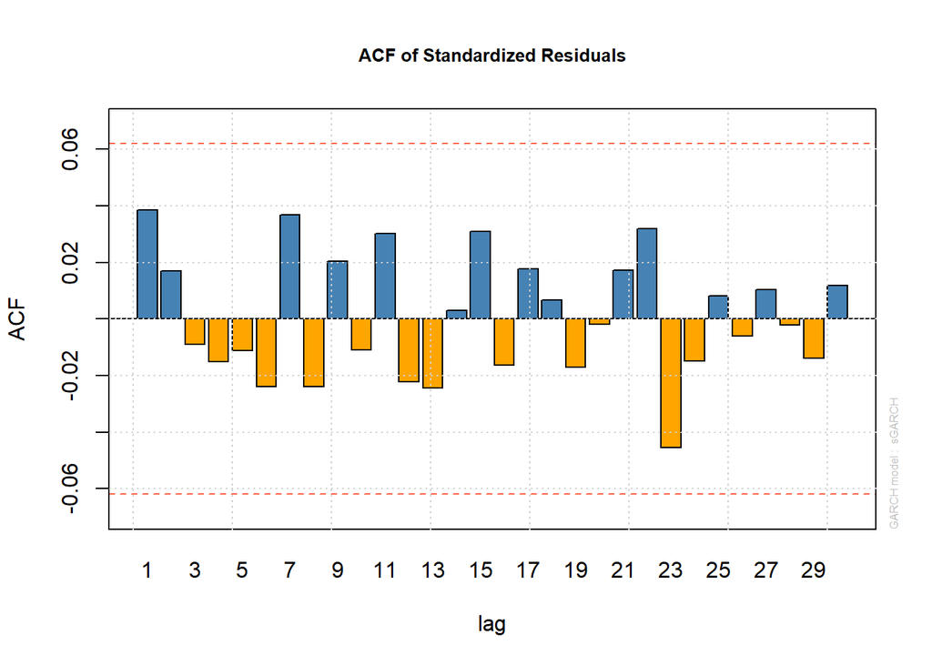

```r
plot_std_residuals(arma55garch22)
```

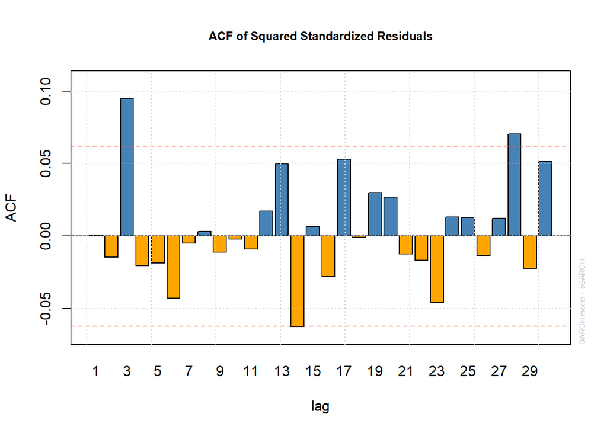

```r
plot_std_sq_residuals(arma55garch22)
```

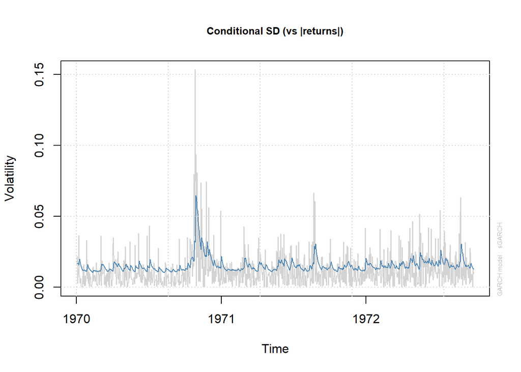

```r
plot_conditional_sd(arma55garch22)
```

#### Comment

- ARCH(2), GARCH(2) are insignificant.
- ACF of standardized residuals showed no significant lags.
- ACF of squared standardized residuals shows significant third lag, 14th and 28th.
- Both Ljung-Box test for standardized squared residuals and LM tests do not allow us to reject null-hypothesis of no autocorrelation of said residuals. Nevertheless, ACF plots are not great, and we can conclude that this model is not that good.

## EGARCH models

In this part, we will try other types of GARCH models, with various parameters. Let’s begin with EGARCH.

### ARMA(0,0)-EGARCH(1,1)

```r
arma00egarch11 <- fit_garch(insample_r$r, 0, 0, 1, 1,model_type = "eGARCH")
arma00egarch11
```

```
##
## *---------------------------------*
## *          GARCH Model Fit        *
## *---------------------------------*
##
## Conditional Variance Dynamics
## -----------------------------------
## GARCH Model  : eGARCH(1,1)
## Mean Model   : ARFIMA(0,0,0)
## Distribution : norm
##
## Optimal Parameters
## ------------------------------------
##         Estimate  Std. Error  t value Pr(>|t|)
## mu      0.000881    0.000446   1.9746 0.048309
## omega  -0.412342    0.115530  -3.5691 0.000358
## alpha1 -0.055345    0.022134  -2.5004 0.012405
## beta1   0.949489    0.013806  68.7720 0.000000
## gamma1  0.196239    0.030539   6.4258 0.000000
##
## Robust Standard Errors:
##         Estimate  Std. Error  t value Pr(>|t|)
## mu      0.000881    0.000459   1.9182 0.055087
## omega  -0.412342    0.117902  -3.4973 0.000470
## alpha1 -0.055345    0.031505  -1.7567 0.078967
## beta1   0.949489    0.013987  67.8817 0.000000
## gamma1  0.196239    0.050290   3.9022 0.000095
##
## LogLikelihood : 2763.746
##
## Information Criteria
## ------------------------------------
##
## Akaike       -5.5120
## Bayes        -5.4875
## Shibata      -5.5120
## Hannan-Quinn -5.5027
##
## Weighted Ljung-Box Test on Standardized Residuals
## ------------------------------------
```

[output cut: 40 more lines]

```
## Negative Sign Bias   1.419 0.1562
## Positive Sign Bias   1.471 0.1417
## Joint Effect         4.494 0.2128
##
##
## Adjusted Pearson Goodness-of-Fit Test:
## ------------------------------------
##   group statistic p-value(g-1)
## 1    20     40.30   0.00298924
## 2    30     56.25   0.00176417
## 3    40     82.76   0.00005511
## 4    50     91.26   0.00023558
##
##
## Elapsed time : 0.7359519
```

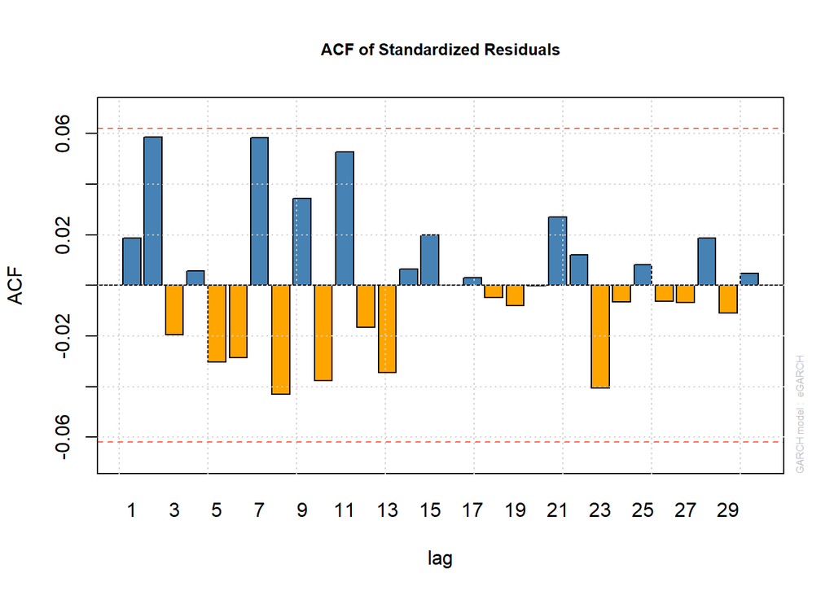

```r
plot_std_residuals(arma00egarch11)
```

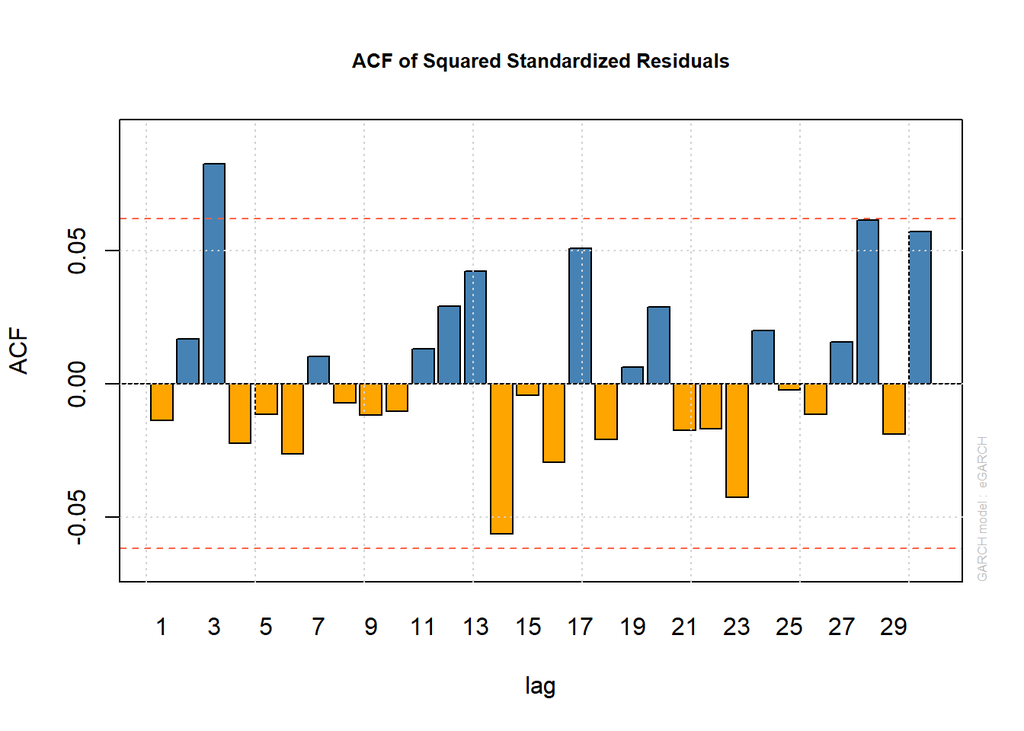

```r
plot_std_sq_residuals(arma00egarch11)
```

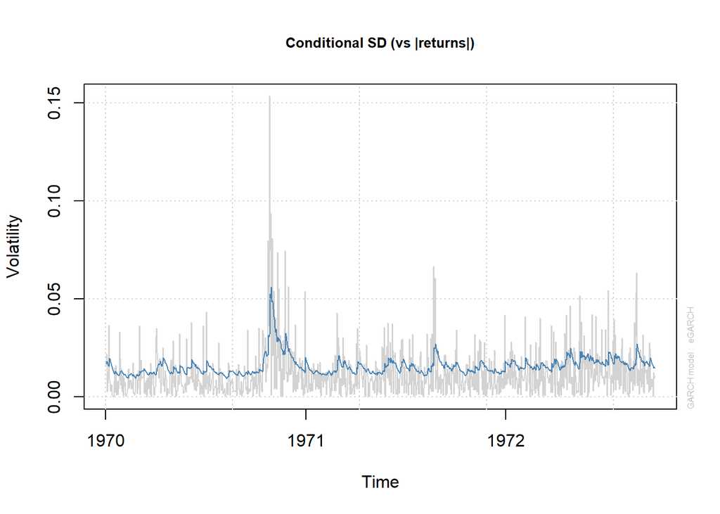

```r
plot_conditional_sd(arma00egarch11)
```

### ARMA(0,0)-EGARCH(2,1)

```r
arma00egarch21 <- fit_garch(insample_r$r, 0, 0, 2, 1,model_type = "eGARCH")
arma00egarch21
```

```
##
## *---------------------------------*
## *          GARCH Model Fit        *
## *---------------------------------*
##
## Conditional Variance Dynamics
## -----------------------------------
## GARCH Model  : eGARCH(2,1)
## Mean Model   : ARFIMA(0,0,0)
## Distribution : norm
##
## Optimal Parameters
## ------------------------------------
##         Estimate  Std. Error  t value Pr(>|t|)
## mu      0.000992    0.000465   2.1319 0.033015
## omega  -0.401807    0.084376  -4.7621 0.000002
## alpha1 -0.146954    0.034998  -4.1989 0.000027
## alpha2  0.101807    0.041507   2.4527 0.014178
## beta1   0.950838    0.009973  95.3372 0.000000
## gamma1  0.113106    0.048461   2.3340 0.019597
## gamma2  0.082187    0.057184   1.4372 0.150650
##
## Robust Standard Errors:
##         Estimate  Std. Error  t value Pr(>|t|)
## mu      0.000992    0.000496   2.0007 0.045426
## omega  -0.401807    0.116048  -3.4624 0.000535
## alpha1 -0.146954    0.061525  -2.3885 0.016917
## alpha2  0.101807    0.053594   1.8996 0.057486
## beta1   0.950838    0.013949  68.1636 0.000000
## gamma1  0.113106    0.064513   1.7532 0.079560
## gamma2  0.082187    0.081847   1.0042 0.315303
##
## LogLikelihood : 2766.745
##
## Information Criteria
## ------------------------------------
##
## Akaike       -5.5140
## Bayes        -5.4796
## Shibata      -5.5141
```

[output cut: 46 more lines]

```
## Negative Sign Bias  1.4436 0.1492
## Positive Sign Bias  0.5752 0.5653
## Joint Effect        2.6333 0.4517
##
##
## Adjusted Pearson Goodness-of-Fit Test:
## ------------------------------------
##   group statistic p-value(g-1)
## 1    20     36.26   0.00979800
## 2    30     62.67   0.00028451
## 3    40     74.20   0.00057328
## 4    50     95.05   0.00008874
##
##
## Elapsed time : 0.4366729
```

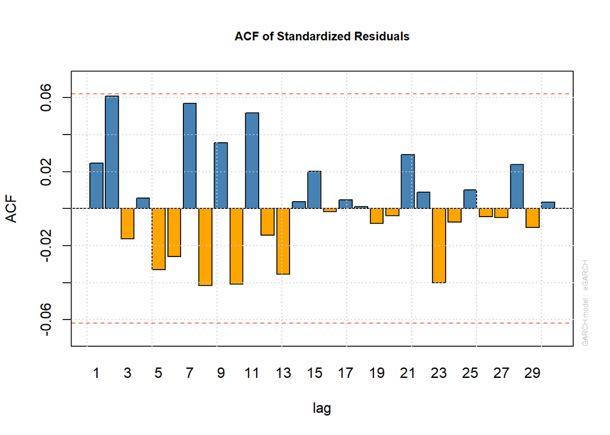

```r
plot_std_residuals(arma00egarch21)
```

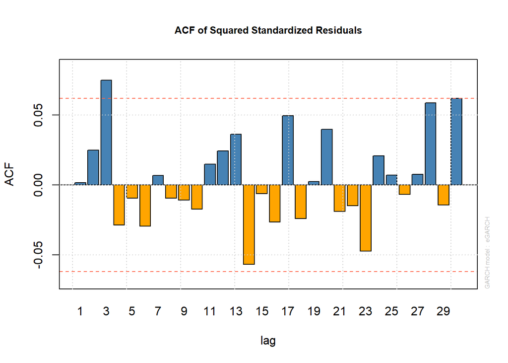

```r
plot_std_sq_residuals(arma00egarch21)
```

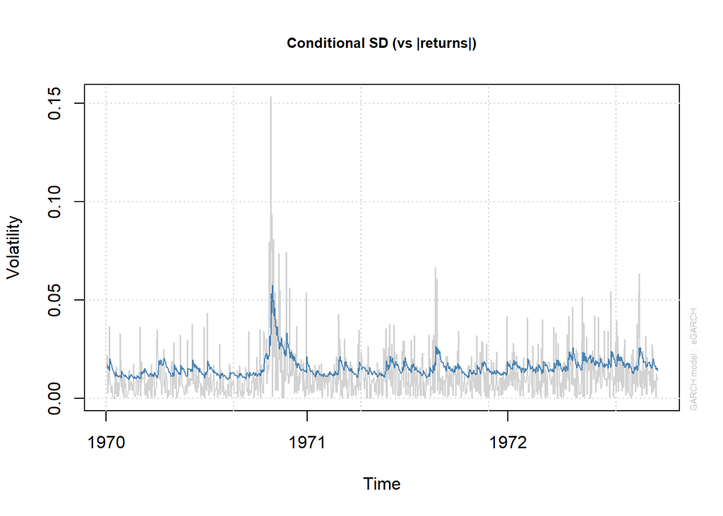

```r
plot_conditional_sd(arma00egarch21)
```

#### Comment

- No evidence of serial correlation in standardized residuals and squared standardized residuals, as indicated by the Ljung-Box tests
- No significant ARCH effects in residuals, according to the LM ARCH test
- The conditional variance dynamics are well-captured by the model parameters

### ARMA(0,0)-EGARCH(1,2)

```r
arma00egarch12 <- fit_garch(insample_r$r, 0, 0, 1, 2, model_type = "eGARCH")
arma00egarch12
```

```
##
## *---------------------------------*
## *          GARCH Model Fit        *
## *---------------------------------*
##
## Conditional Variance Dynamics
## -----------------------------------
## GARCH Model  : eGARCH(1,2)
## Mean Model   : ARFIMA(0,0,0)
## Distribution : norm
##
## Optimal Parameters
## ------------------------------------
##         Estimate  Std. Error  t value Pr(>|t|)
## mu      0.000889    0.000449   1.9816 0.047518
## omega  -0.393548    0.114999  -3.4222 0.000621
## alpha1 -0.052245    0.021597  -2.4191 0.015560
## beta1   0.996350    0.009452 105.4137 0.000000
## beta2  -0.044571    0.008835  -5.0447 0.000000
## gamma1  0.188541    0.025535   7.3836 0.000000
##
## Robust Standard Errors:
##         Estimate  Std. Error  t value Pr(>|t|)
## mu      0.000889    0.000483   1.8423 0.065430
## omega  -0.393548    0.125009  -3.1482 0.001643
## alpha1 -0.052245    0.031537  -1.6566 0.097592
## beta1   0.996350    0.013503  73.7882 0.000000
## beta2  -0.044571    0.014549  -3.0635 0.002188
## gamma1  0.188541    0.034446   5.4735 0.000000
##
## LogLikelihood : 2763.817
##
## Information Criteria
## ------------------------------------
##
## Akaike       -5.5101
## Bayes        -5.4807
## Shibata      -5.5102
## Hannan-Quinn -5.4989
##
```

[output cut: 43 more lines]

```
## Negative Sign Bias   1.493 0.1359
## Positive Sign Bias   1.454 0.1462
## Joint Effect         4.706 0.1947
##
##
## Adjusted Pearson Goodness-of-Fit Test:
## ------------------------------------
##   group statistic p-value(g-1)
## 1    20     40.14    0.0031377
## 2    30     56.43    0.0016794
## 3    40     75.96    0.0003600
## 4    50     90.66    0.0002739
##
##
## Elapsed time : 0.4795501
```

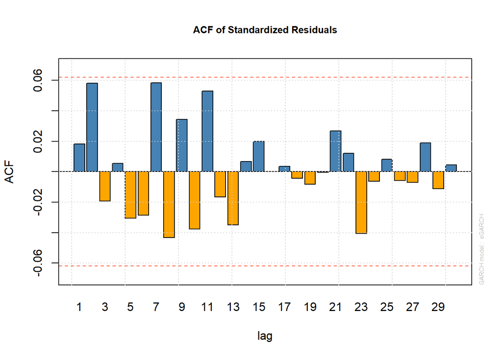

```r
plot_std_residuals(arma00egarch12)
```

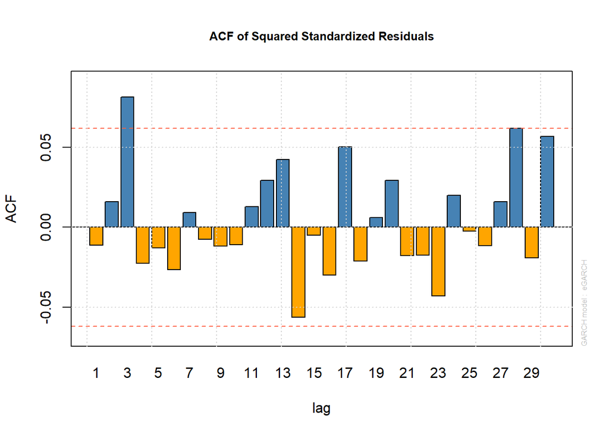

```r
plot_std_sq_residuals(arma00egarch12)
```

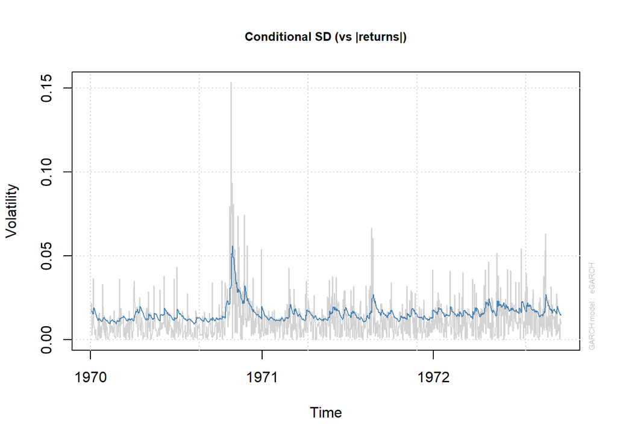

```r
plot_conditional_sd(arma00egarch12)
```

#### Comment

- No evidence of serial correlation in standardized residuals and squared standardized residuals, as indicated by the Ljung-Box tests
- No significant ARCH effects in residuals, according to the LM ARCH test
- The conditional variance dynamics are well-captured by the model parameters

### ARMA(5,5)-EGARCH(2,1)

```r
arma55egarch21 <- fit_garch(insample_r$r, 5, 5, 2, 1, model_type = "eGARCH")
arma55egarch21
```

```
##
## *---------------------------------*
## *          GARCH Model Fit        *
## *---------------------------------*
##
## Conditional Variance Dynamics
## -----------------------------------
## GARCH Model  : eGARCH(2,1)
## Mean Model   : ARFIMA(5,0,5)
## Distribution : norm
##
## Optimal Parameters
## ------------------------------------
##         Estimate  Std. Error     t value Pr(>|t|)
## mu      0.001299    0.000041     31.8566 0.000000
## ar1    -1.239032    0.000664  -1866.2766 0.000000
## ar2    -1.181832    0.000658  -1795.1099 0.000000
## ar3    -1.096081    0.000537  -2039.7457 0.000000
## ar4    -0.574753    0.000263  -2186.3007 0.000000
## ar5     0.178535    0.000476    375.4515 0.000000
## ma1     1.233690    0.000014  88113.3011 0.000000
## ma2     1.254579    0.000090  13876.0752 0.000000
## ma3     1.191495    0.000011 103965.3869 0.000000
## ma4     0.650839    0.000149   4358.2907 0.000000
## ma5    -0.161400    0.000069  -2338.1387 0.000000
## omega  -0.437674    0.064988     -6.7347 0.000000
## alpha1 -0.142634    0.020789     -6.8611 0.000000
## alpha2  0.093977    0.003501     26.8444 0.000000
## beta1   0.946881    0.007410    127.7791 0.000000
## gamma1  0.099999    0.008728     11.4571 0.000000
## gamma2  0.119600    0.031760      3.7657 0.000166
##
## Robust Standard Errors:
##         Estimate  Std. Error    t value Pr(>|t|)
## mu      0.001299    0.000032    40.0030 0.000000
## ar1    -1.239032    0.000596 -2079.3173 0.000000
## ar2    -1.181832    0.000959 -1232.6348 0.000000
## ar3    -1.096081    0.000344 -3184.4283 0.000000
## ar4    -0.574753    0.000414 -1389.0204 0.000000
## ar5     0.178535    0.000499   357.9871 0.000000
```

[output cut: 76 more lines]

```
## Negative Sign Bias  1.2083 0.2272
## Positive Sign Bias  0.5064 0.6127
## Joint Effect        1.7457 0.6268
##
##
## Adjusted Pearson Goodness-of-Fit Test:
## ------------------------------------
##   group statistic p-value(g-1)
## 1    20     45.61   0.00056205
## 2    30     69.38   0.00003685
## 3    40     70.21   0.00159386
## 4    50     78.57   0.00464709
##
##
## Elapsed time : 3.496656
```

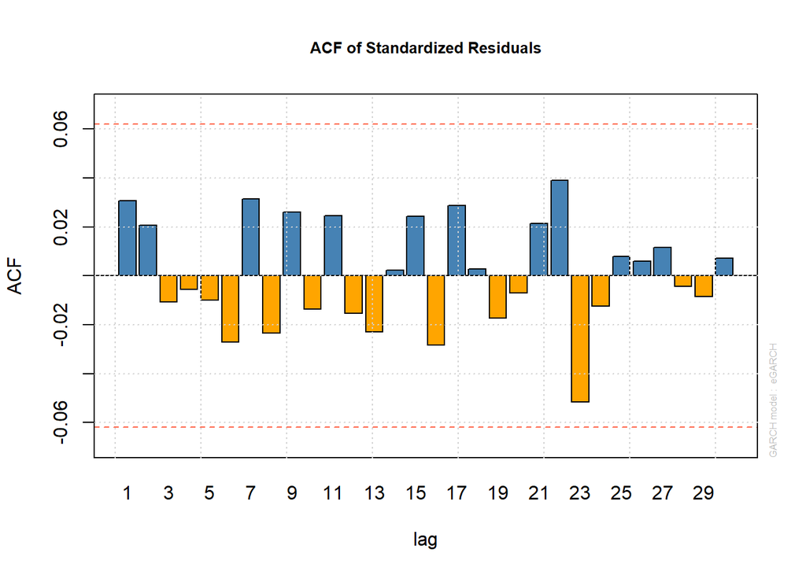

```r
plot_std_residuals(arma55egarch21)
```

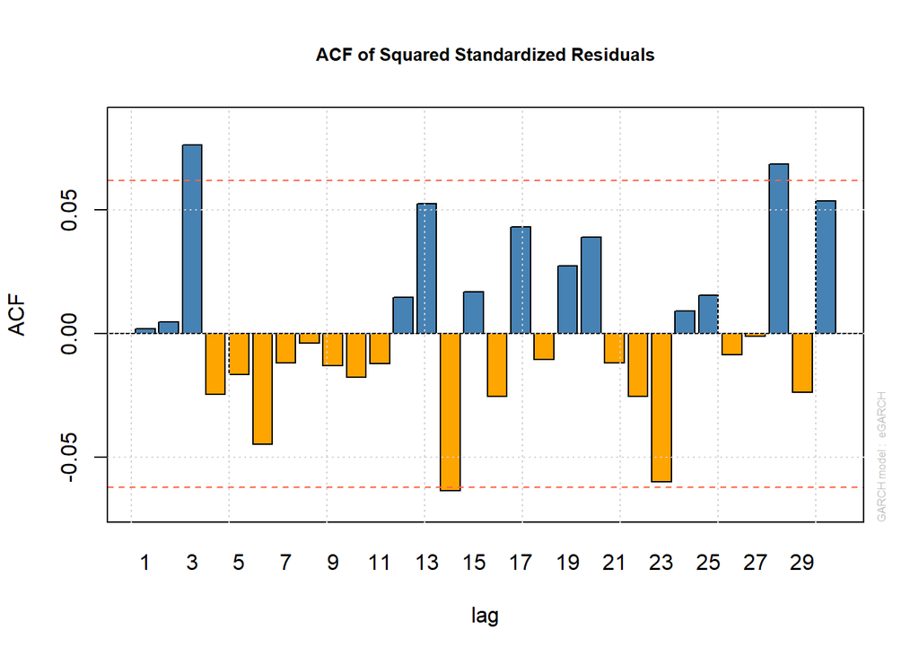

```r
plot_std_sq_residuals(arma55egarch21)
```

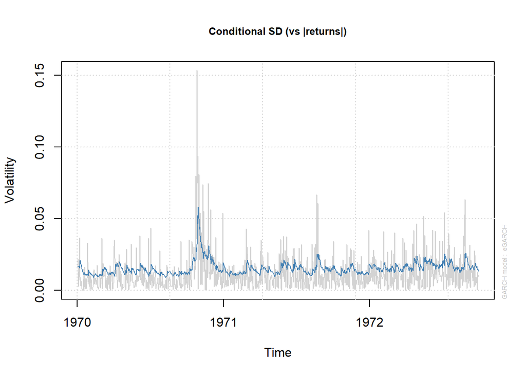

```r
plot_conditional_sd(arma55egarch21)
```

#### Comment

- No evidence of serial correlation in standardized residuals and squared standardized residuals, as indicated by the Ljung-Box tests
- No significant ARCH effects in residuals, according to the LM ARCH test
- The conditional variance dynamics are well-captured by the model parameters

## TGARCH Models

Now, let’s try some TGARCH models.

### ARMA(0,0)-TGARCH(1,1)

```r
arma00tgarch11 <- fit_garch(insample_r$r, 0, 0, 1, 1, model_type = "fGARCH", submodel = "TGARCH")
arma00tgarch11
```

```
##
## *---------------------------------*
## *          GARCH Model Fit        *
## *---------------------------------*
##
## Conditional Variance Dynamics
## -----------------------------------
## GARCH Model  : fGARCH(1,1)
## fGARCH Sub-Model : TGARCH
## Mean Model   : ARFIMA(0,0,0)
## Distribution : norm
##
## Optimal Parameters
## ------------------------------------
##         Estimate  Std. Error  t value Pr(>|t|)
## mu      0.000857    0.000437   1.9625 0.049701
## omega   0.000953    0.000351   2.7171 0.006585
## alpha1  0.108260    0.020844   5.1938 0.000000
## beta1   0.858416    0.033016  26.0002 0.000000
## eta11   0.354241    0.141235   2.5082 0.012136
##
## Robust Standard Errors:
##         Estimate  Std. Error  t value Pr(>|t|)
## mu      0.000857    0.000450   1.9057 0.056692
## omega   0.000953    0.000548   1.7392 0.081997
## alpha1  0.108260    0.040004   2.7062 0.006806
## beta1   0.858416    0.058294  14.7255 0.000000
## eta11   0.354241    0.186836   1.8960 0.057961
##
## LogLikelihood : 2764.978
##
## Information Criteria
## ------------------------------------
##
## Akaike       -5.5144
## Bayes        -5.4899
## Shibata      -5.5145
## Hannan-Quinn -5.5051
##
## Weighted Ljung-Box Test on Standardized Residuals
```

[output cut: 41 more lines]

```
## Negative Sign Bias   1.292 0.1967
## Positive Sign Bias   1.526 0.1274
## Joint Effect         4.101 0.2507
##
##
## Adjusted Pearson Goodness-of-Fit Test:
## ------------------------------------
##   group statistic p-value(g-1)
## 1    20     35.94     0.010727
## 2    30     55.29     0.002289
## 3    40     73.25     0.000736
## 4    50     84.36     0.001261
##
##
## Elapsed time : 0.765486
```

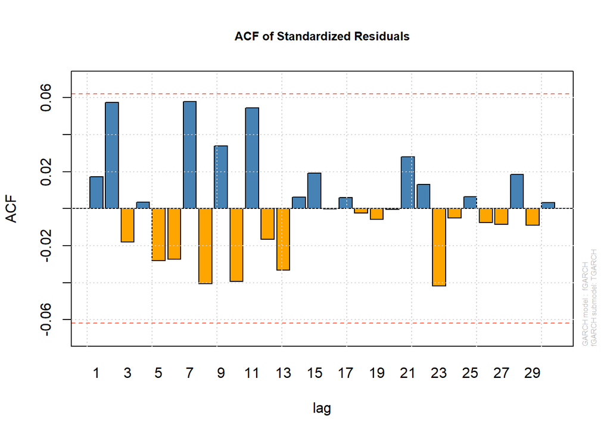

```r
plot_std_residuals(arma00tgarch11)
```

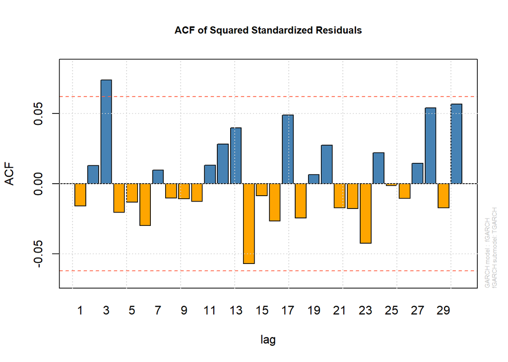

```r
plot_std_sq_residuals(arma00tgarch11)
```

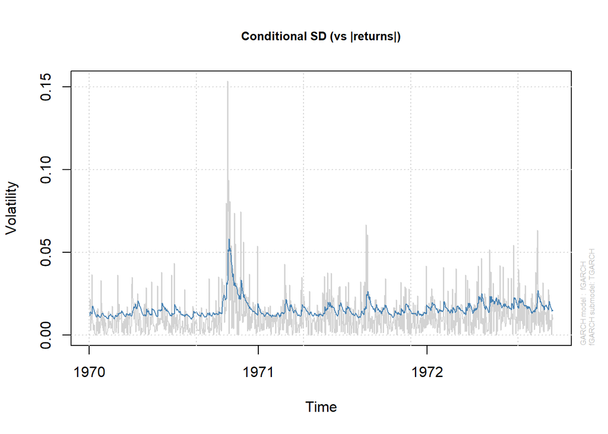

```r
plot_conditional_sd(arma00tgarch11)
```

#### Comment

- No evidence of serial correlation in standardized residuals and squared standardized residuals, as indicated by the Ljung-Box tests
- Some evidence of ARCH effects in residuals at lag 3, according to the LM ARCH test, suggesting potential remaining ARCH effects
- The conditional variance dynamics are well-captured by the model parameters

### ARMA(0,0)-TGARCH(1,2)

```r
arma00tgarch12 <- fit_garch(insample_r$r, 0, 0, 1, 2, model_type = "fGARCH", submodel = "TGARCH")
arma00tgarch12
```

```
##
## *---------------------------------*
## *          GARCH Model Fit        *
## *---------------------------------*
##
## Conditional Variance Dynamics
## -----------------------------------
## GARCH Model  : fGARCH(1,2)
## fGARCH Sub-Model : TGARCH
## Mean Model   : ARFIMA(0,0,0)
## Distribution : norm
##
## Optimal Parameters
## ------------------------------------
##         Estimate  Std. Error  t value Pr(>|t|)
## mu      0.000754    0.000479  1.57477 0.115311
## omega   0.001124    0.000349  3.22542 0.001258
## alpha1  0.131004    0.020155  6.49996 0.000000
## beta1   0.011102    0.028644  0.38758 0.698327
## beta2   0.819751    0.034999 23.42212 0.000000
## eta11   0.410775    0.119481  3.43799 0.000586
##
## Robust Standard Errors:
##         Estimate  Std. Error  t value Pr(>|t|)
## mu      0.000754    0.000539  1.39925 0.161739
## omega   0.001124    0.000455  2.47007 0.013509
## alpha1  0.131004    0.041015  3.19405 0.001403
## beta1   0.011102    0.034109  0.32548 0.744818
## beta2   0.819751    0.044068 18.60202 0.000000
## eta11   0.410775    0.146610  2.80181 0.005082
##
## LogLikelihood : 2766.29
##
## Information Criteria
## ------------------------------------
##
## Akaike       -5.5151
## Bayes        -5.4856
## Shibata      -5.5151
## Hannan-Quinn -5.5039
```

[output cut: 44 more lines]

```
## Negative Sign Bias  1.0956 0.2735
## Positive Sign Bias  0.9683 0.3332
## Joint Effect        2.1385 0.5442
##
##
## Adjusted Pearson Goodness-of-Fit Test:
## ------------------------------------
##   group statistic p-value(g-1)
## 1    20     38.02   0.00589834
## 2    30     57.57   0.00122623
## 3    40     75.32   0.00042683
## 4    50     97.25   0.00004964
##
##
## Elapsed time : 0.9004252
```

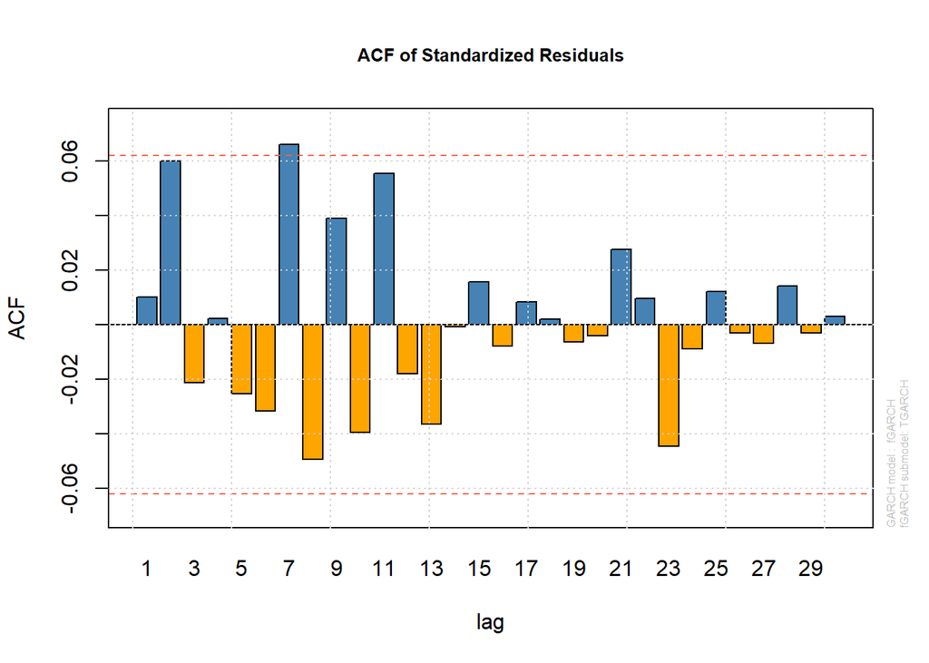

```r
plot_std_residuals(arma00tgarch12)
```

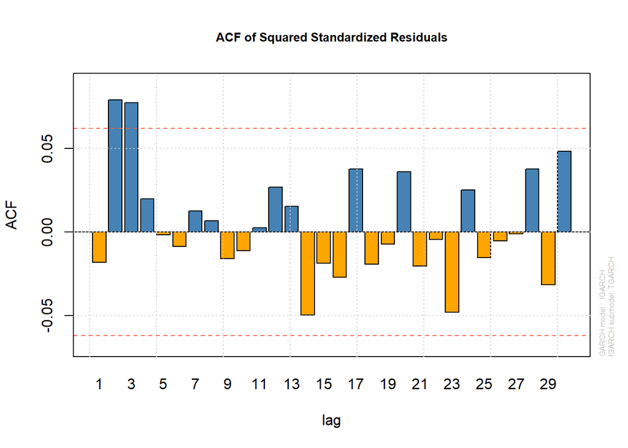

```r
plot_std_sq_residuals(arma00tgarch12)
```

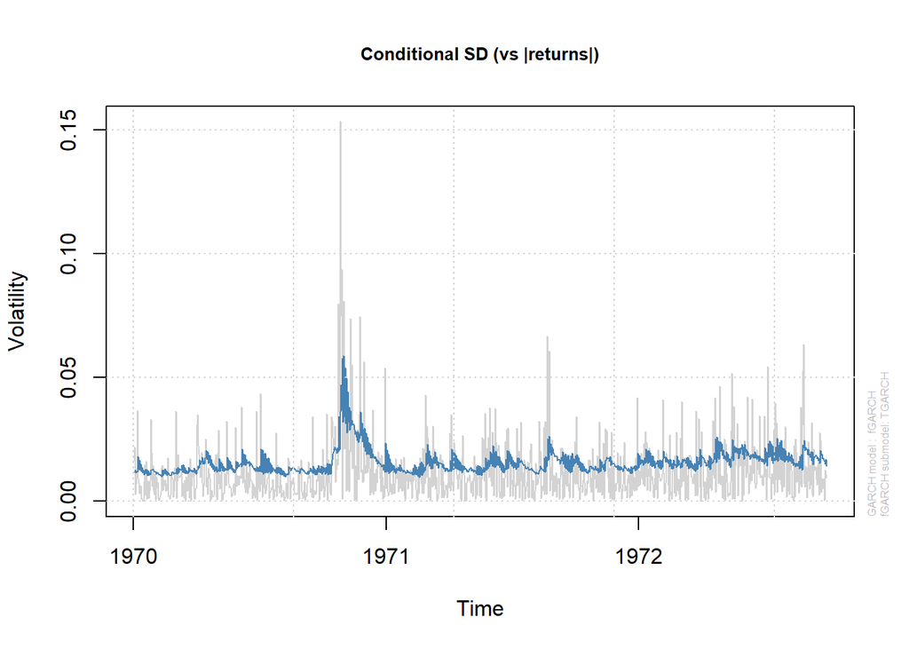

```r
plot_conditional_sd(arma00tgarch12)
```

#### Comment

- No evidence of serial correlation in standardized residuals, as indicated by the Ljung-Box tests
- Some evidence of autocorrelation in squared standardized residuals at certain lags, indicating potential remaining ARCH effects
- No significant ARCH effects in residuals, according to the LM test
- The conditional variance dynamics are well-captured by the model parameters
- Stability and bias tests show no significant issues.

### ARMA(0,0)-TGARCH(2,1)

```r
arma00tgarch21 <- fit_garch(insample_r$r, 0, 0, 2,1,model_type = "fGARCH", submodel = "TGARCH")
arma00tgarch21
```

```
##
## *---------------------------------*
## *          GARCH Model Fit        *
## *---------------------------------*
##
## Conditional Variance Dynamics
## -----------------------------------
## GARCH Model  : fGARCH(2,1)
## fGARCH Sub-Model : TGARCH
## Mean Model   : ARFIMA(0,0,0)
## Distribution : norm
##
## Optimal Parameters
## ------------------------------------
##         Estimate  Std. Error   t value Pr(>|t|)
## mu      0.000858    0.000435  1.972886 0.048509
## omega   0.000929    0.000343  2.708630 0.006756
## alpha1  0.107209    0.020668  5.187136 0.000000
## alpha2  0.000000    0.000009  0.000002 0.999998
## beta1   0.860744    0.032464 26.514141 0.000000
## eta11   0.342675    0.139737  2.452280 0.014195
## eta12   0.329824    0.563631  0.585178 0.558428
##
## Robust Standard Errors:
##         Estimate  Std. Error   t value Pr(>|t|)
## mu      0.000858    0.000445  1.927679 0.053895
## omega   0.000929    0.000536  1.733382 0.083028
## alpha1  0.107209    0.040057  2.676397 0.007442
## alpha2  0.000000    0.000000  0.003484 0.997220
## beta1   0.860744    0.057629 14.935956 0.000000
## eta11   0.342675    0.184856  1.853743 0.063776
## eta12   0.329824    0.831705  0.396564 0.691689
##
## LogLikelihood : 2764.583
##
## Information Criteria
## ------------------------------------
##
## Akaike       -5.5097
## Bayes        -5.4753
```

[output cut: 47 more lines]

```
## Negative Sign Bias   1.335 0.1822
## Positive Sign Bias   1.515 0.1301
## Joint Effect         4.201 0.2406
##
##
## Adjusted Pearson Goodness-of-Fit Test:
## ------------------------------------
##   group statistic p-value(g-1)
## 1    20     33.35    0.0219237
## 2    30     55.47    0.0021807
## 3    40     71.09    0.0012783
## 4    50     90.06    0.0003183
##
##
## Elapsed time : 1.299761
```

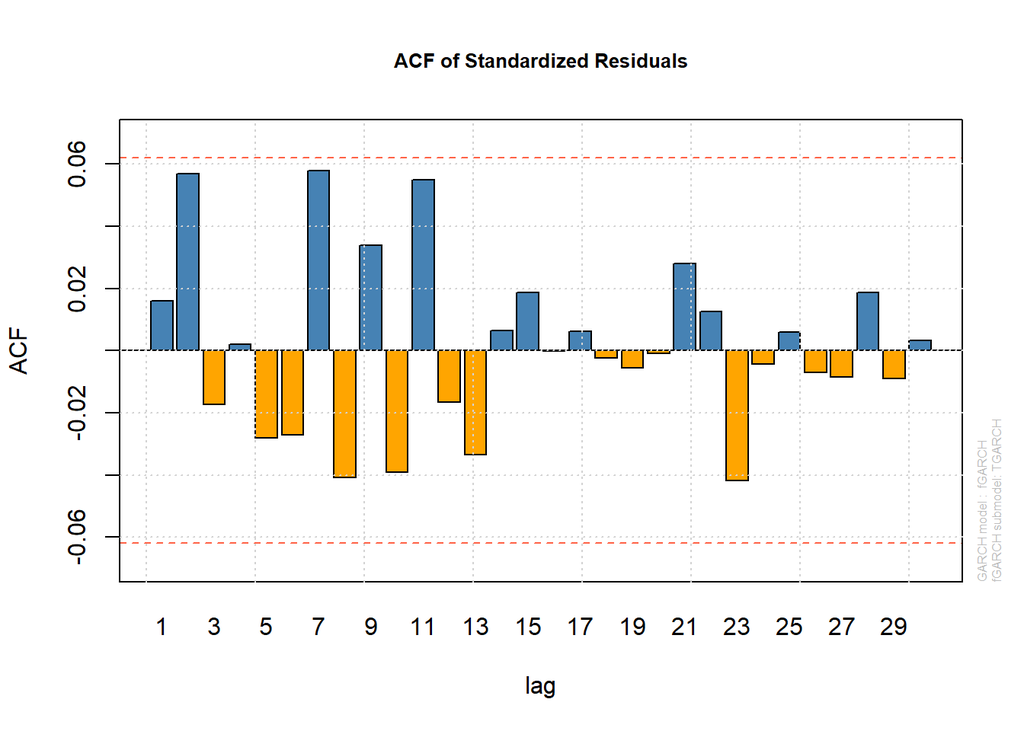

```r
plot_std_residuals(arma00tgarch21)
```

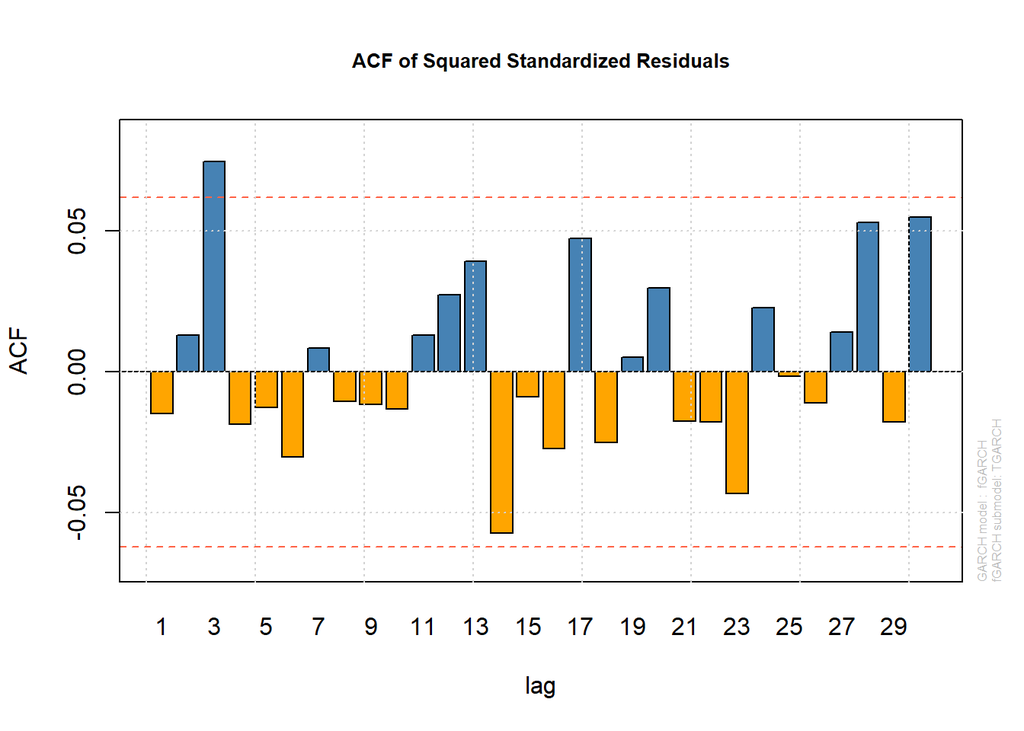

```r
plot_std_sq_residuals(arma00tgarch21)
```

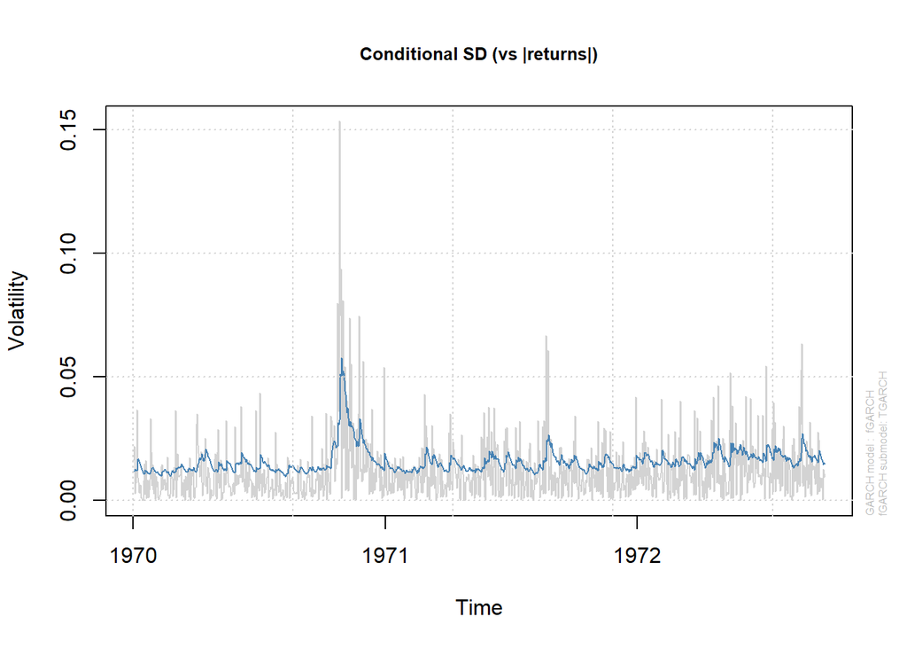

```r
plot_conditional_sd(arma00tgarch21)
```

#### Comment

- No evidence of serial correlation in standardized residuals and squared standardized residuals, as indicated by the Ljung-Box tests.
- No significant ARCH effects in residuals, according to the LM ARCH test.
- The conditional variance dynamics are well-captured by the model parameters.
- Stability and bias tests show no significant issues.

### ARMA(5,5)-TGARCH(2,1)

```r
arma55tgarch21 <- fit_garch(insample_r$r, 5, 5, 2, 1, model_type = "fGARCH", submodel = "TGARCH")
arma55tgarch21
```

```
##
## *---------------------------------*
## *          GARCH Model Fit        *
## *---------------------------------*
##
## Conditional Variance Dynamics
## -----------------------------------
## GARCH Model  : fGARCH(2,1)
## fGARCH Sub-Model : TGARCH
## Mean Model   : ARFIMA(5,0,5)
## Distribution : norm
##
## Optimal Parameters
## ------------------------------------
##         Estimate  Std. Error      t value Pr(>|t|)
## mu      0.000884    0.000097     9.134765 0.000000
## ar1    -1.182202    0.002087  -566.369456 0.000000
## ar2    -0.676637    0.002231  -303.322198 0.000000
## ar3    -0.843892    0.001908  -442.230381 0.000000
## ar4    -0.127944    0.000937  -136.529387 0.000000
## ar5     0.484999    0.000658   737.101682 0.000000
## ma1     1.168306    0.000393  2973.386353 0.000000
## ma2     0.715311    0.000251  2852.819960 0.000000
## ma3     0.933604    0.000339  2750.942463 0.000000
## ma4     0.161108    0.000134  1200.188311 0.000000
## ma5    -0.490711    0.000178 -2760.006860 0.000000
## omega   0.000974    0.000560     1.738367 0.082146
## alpha1  0.123054    0.023970     5.133616 0.000000
## alpha2  0.000000    0.000015     0.000001 0.999999
## beta1   0.844311    0.043320    19.490169 0.000000
## eta11   0.368757    0.172836     2.133569 0.032878
## eta12   0.260570    0.634298     0.410801 0.681219
##
## Robust Standard Errors:
##         Estimate  Std. Error      t value Pr(>|t|)
## mu      0.000884    0.000117     7.543394  0.00000
## ar1    -1.182202    0.003228  -366.286689  0.00000
## ar2    -0.676637    0.002526  -267.884006  0.00000
## ar3    -0.843892    0.003538  -238.554330  0.00000
## ar4    -0.127944    0.001488   -85.983236  0.00000
```

[output cut: 77 more lines]

```
## Negative Sign Bias  0.9566 0.3390
## Positive Sign Bias  1.4870 0.1373
## Joint Effect        3.1879 0.3636
##
##
## Adjusted Pearson Goodness-of-Fit Test:
## ------------------------------------
##   group statistic p-value(g-1)
## 1    20     38.78     0.004715
## 2    30     43.13     0.044324
## 3    40     58.46     0.023321
## 4    50     74.07     0.011862
##
##
## Elapsed time : 6.305833
```

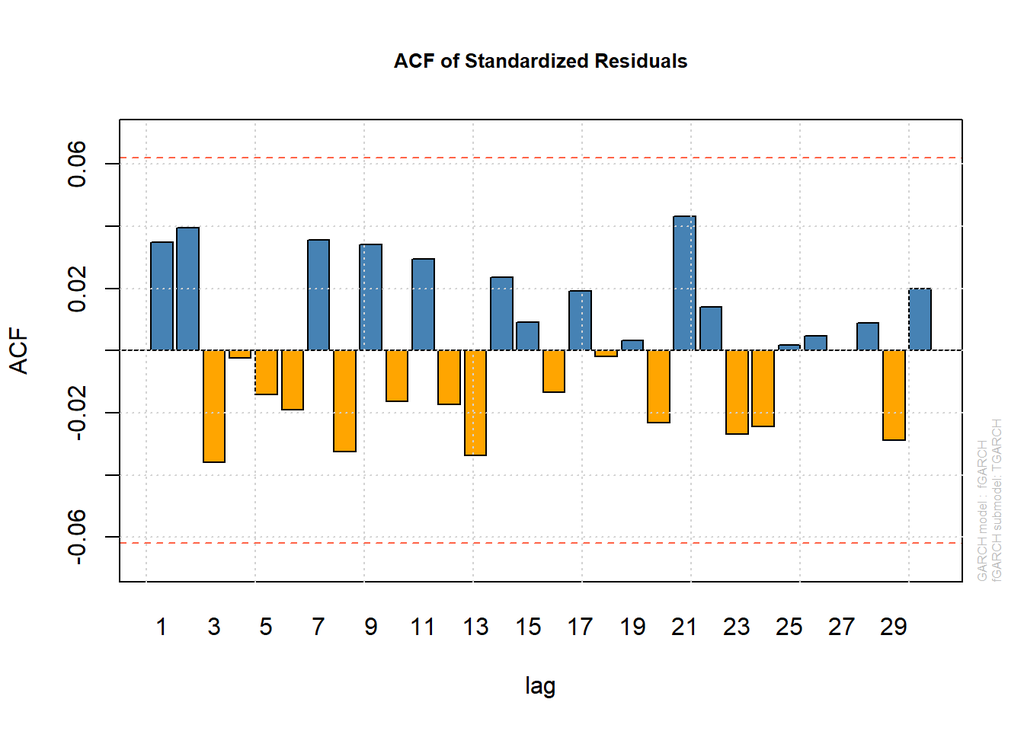

```r
plot_std_residuals(arma55tgarch21)
```

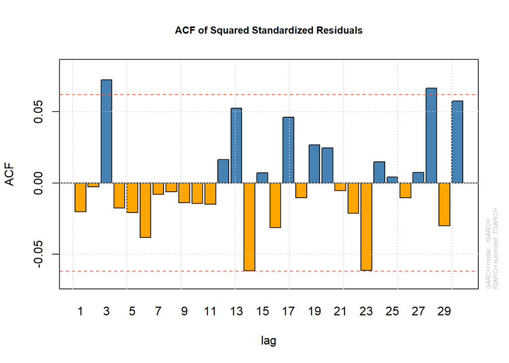

```r
plot_std_sq_residuals(arma55tgarch21)
```

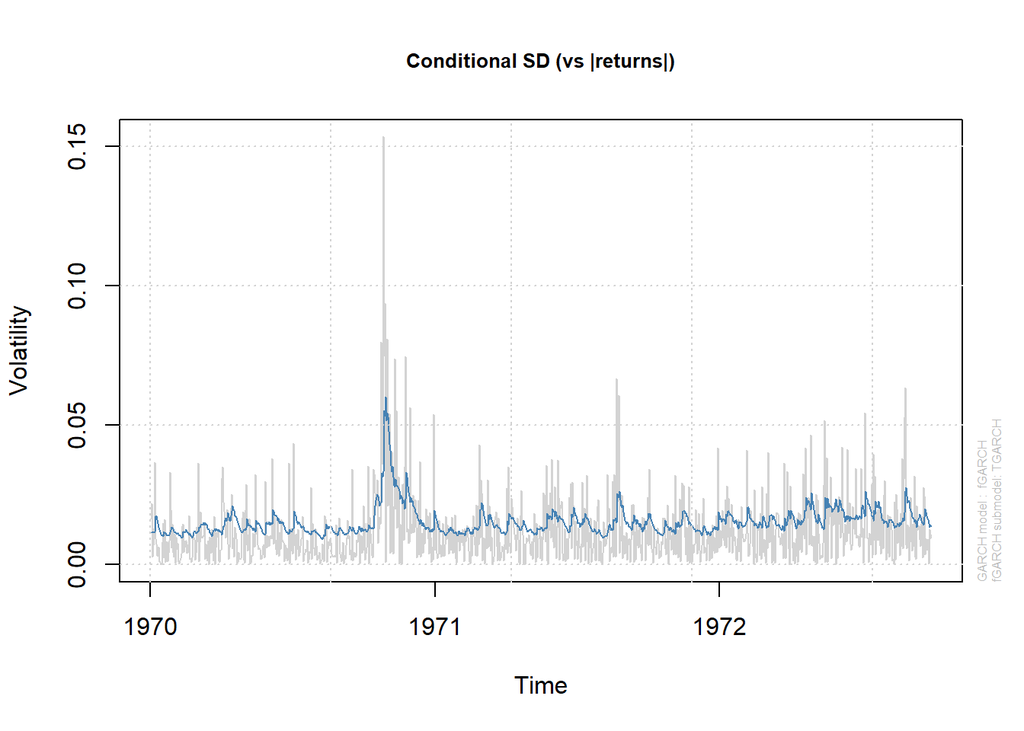

```r
plot_conditional_sd(arma55tgarch21)
```

#### Comment

- No evidence of serial correlation in standardized residuals and squared standardized residuals, as indicated by the Ljung-Box tests
- No significant ARCH effects in residuals, according to the LM ARCH test
- The conditional variance dynamics are well-captured by the model parameters
- Stability and bias tests show no significant issues.

### ARMA(5,5)-TGARCH(1,2)

```r
arma55tgarch12 <- fit_garch(insample_r$r, 5, 5, 1, 2,model_type = "fGARCH", submodel = "TGARCH")
arma55tgarch12
```

```
##
## *---------------------------------*
## *          GARCH Model Fit        *
## *---------------------------------*
##
## Conditional Variance Dynamics
## -----------------------------------
## GARCH Model  : fGARCH(1,2)
## fGARCH Sub-Model : TGARCH
## Mean Model   : ARFIMA(5,0,5)
## Distribution : norm
##
## Optimal Parameters
## ------------------------------------
##         Estimate  Std. Error    t value Pr(>|t|)
## mu      0.000901    0.000349   2.585353 0.009728
## ar1    -0.943228    0.017956 -52.529829 0.000000
## ar2    -0.000536    0.014635  -0.036593 0.970809
## ar3    -0.535520    0.007719 -69.377425 0.000000
## ar4    -1.120859    0.014211 -78.873578 0.000000
## ar5    -0.460408    0.023113 -19.920212 0.000000
## ma1     0.942425    0.001591 592.281508 0.000000
## ma2     0.027135    0.001632  16.625574 0.000000
## ma3     0.526961    0.000662 795.497424 0.000000
## ma4     1.122205    0.001133 990.414439 0.000000
## ma5     0.520758    0.001152 451.960382 0.000000
## omega   0.001162    0.000368   3.161453 0.001570
## alpha1  0.140105    0.021925   6.390127 0.000000
## beta1   0.002569    0.027717   0.092672 0.926164
## beta2   0.816297    0.032560  25.070738 0.000000
## eta11   0.388654    0.107865   3.603165 0.000314
##
## Robust Standard Errors:
##         Estimate  Std. Error     t value Pr(>|t|)
## mu      0.000901    0.000280    3.216420 0.001298
## ar1    -0.943228    0.021685  -43.496093 0.000000
## ar2    -0.000536    0.014791   -0.036207 0.971117
## ar3    -0.535520    0.006564  -81.581773 0.000000
## ar4    -1.120859    0.017700  -63.324051 0.000000
## ar5    -0.460408    0.029016  -15.867311 0.000000
```

[output cut: 74 more lines]

```
## Negative Sign Bias   1.423 0.1551
## Positive Sign Bias   1.091 0.2754
## Joint Effect         3.241 0.3559
##
##
## Adjusted Pearson Goodness-of-Fit Test:
## ------------------------------------
##   group statistic p-value(g-1)
## 1    20     41.18   0.00228521
## 2    30     45.52   0.02615383
## 3    40     84.35   0.00003484
## 4    50     81.87   0.00224065
##
##
## Elapsed time : 4.393244
```

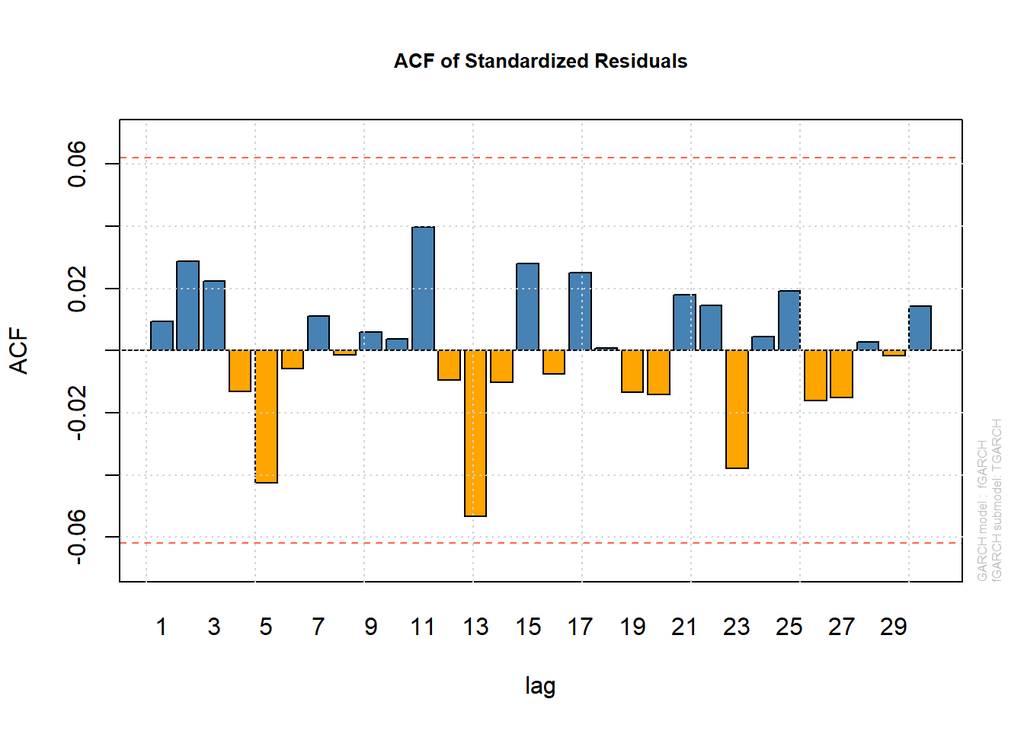

```r
plot_std_residuals(arma55tgarch12)
```

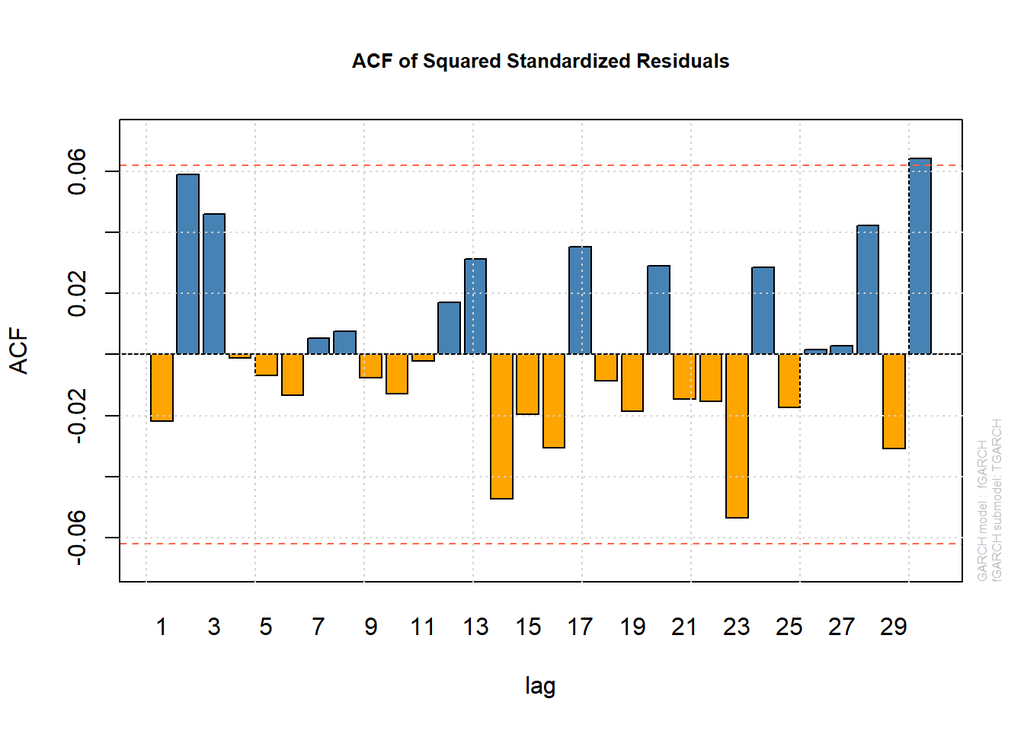

```r
plot_std_sq_residuals(arma55tgarch12)
```

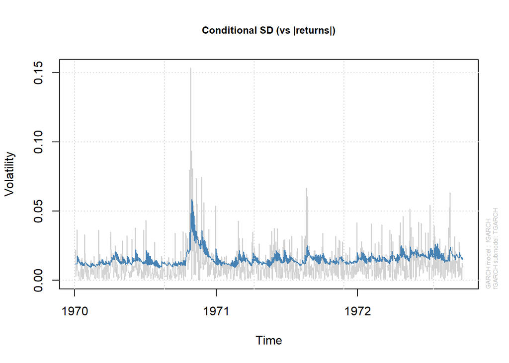

```r
plot_conditional_sd(arma55tgarch12)
```

#### Comment

- No evidence of serial correlation in standardized residuals and squared standardized residuals, as indicated by the Ljung-Box tests
- No significant ARCH effects in residuals, according to the LM ARCH test
- The conditional variance dynamics are well-captured by the model parameters
- Stability and bias tests show no significant issues.

### Model Selection

Since for most models LM and LB tests have not been able to reject null-hypothesis of no standardized simple/squared residuals autocorrelation, and the 3rd ACF lag for standardized squared residuals has not been removed fully by most of the models as well, we decide to choose among models which are the simplest and/or have the largest number of significant coefficient estimations.

For other GARCH models we select ARMA(0,0)-EGARCH(2,1), ARMA(5,5)-EGARCH(2,1) and ARMA(5,5)-TGARCH(2,1)

```r
compare_ICs_GARCH <- function(models_list) {
  n <- length(models_list)

  for(i in 1:n) {
    ICs_ <- data.frame(t(infocriteria(models_list[[i]])))
    if(i == 1) ICs <- ICs_ else ICs <- rbind(ICs, ICs_)
  }

  mins <- sapply(ICs[,1:(ncol(ICs)-1)], function(x) which(x == min(x)))

  return(list(ICs = ICs, which.min = mins))
}

candidate_models_list <- c(arma00garch21, arma55garch21, arma77garch21, arma00egarch21, arma55egarch21, arma55tgarch21)

ic_compare <- compare_ICs_GARCH(candidate_models_list)
ic_compare
```

```
## $ICs
##      Akaike     Bayes   Shibata Hannan.Quinn
## 1 -5.507269 -5.482750 -5.507319    -5.497951
## 2 -5.520163 -5.446605 -5.520604    -5.492208
## 3 -5.508266 -5.415093 -5.508969    -5.472856
## 4 -5.513977 -5.479650 -5.514074    -5.500931
## 5 -5.542762 -5.459396 -5.543326    -5.511079
## 6 -5.540513 -5.457148 -5.541077    -5.508830
##
## $which.min
##  Akaike   Bayes Shibata
##       5       1       5
```

Based on information criteria comparison, ARMA(5,5)-EGARCH(2,1) is the best for all criteria except BIC, where ARMA(0,0)-GARCH(2,1) is the best. Let’s then choose these two models as final ones.

```r
chosen_garch = function(returns){
  return(fit_garch(returns, 0, 0, 2, 1))
}
```

```r
chosen_mod_garch = function(returns){
  return(fit_garch(returns, 5, 5, 2, 1, model_type = "eGARCH"))
}
```

# Futher Diagnostics

## ARMA(0,0)-GARCH(2,1)

```r
arma00garch21
```

```
##
## *---------------------------------*
## *          GARCH Model Fit        *
## *---------------------------------*
##
## Conditional Variance Dynamics
## -----------------------------------
## GARCH Model  : sGARCH(2,1)
## Mean Model   : ARFIMA(0,0,0)
## Distribution : norm
##
## Optimal Parameters
## ------------------------------------
##         Estimate  Std. Error  t value Pr(>|t|)
## mu      0.001093    0.000454   2.4068 0.016093
## omega   0.000017    0.000007   2.4021 0.016303
## alpha1  0.059986    0.032249   1.8601 0.062872
## alpha2  0.053556    0.036459   1.4689 0.141847
## beta1   0.822957    0.038129  21.5835 0.000000
##
## Robust Standard Errors:
##         Estimate  Std. Error  t value Pr(>|t|)
## mu      0.001093    0.000515  2.11982 0.034021
## omega   0.000017    0.000024  0.69768 0.485378
## alpha1  0.059986    0.048606  1.23413 0.217155
## alpha2  0.053556    0.055032  0.97318 0.330465
## beta1   0.822957    0.101610  8.09913 0.000000
##
## LogLikelihood : 2761.388
##
## Information Criteria
## ------------------------------------
##
## Akaike       -5.5073
## Bayes        -5.4827
## Shibata      -5.5073
## Hannan-Quinn -5.4980
##
## Weighted Ljung-Box Test on Standardized Residuals
## ------------------------------------
```

[output cut: 40 more lines]

```
## Negative Sign Bias   2.215 0.02702  **
## Positive Sign Bias   1.668 0.09561   *
## Joint Effect         8.566 0.03566  **
##
##
## Adjusted Pearson Goodness-of-Fit Test:
## ------------------------------------
##   group statistic p-value(g-1)
## 1    20     41.94    0.0018074
## 2    30     60.15    0.0005919
## 3    40     78.12    0.0002010
## 4    50     94.55    0.0001011
##
##
## Elapsed time : 0.300513
```

#### Parameters

As mentioned previously, ARCH(1) and ARCH(2) are insignificant.

Mu is an estimated mean of log-returns. It is close to zero, which is expected for log-returns. Omega is an intercept of conditional variance equation. It is positive and very close to zero. ARCH parameters are positive but small, indicating that lagged shocks somewhat influence the current conditional variance GARCH(1) of 0.82 shows strong influence of lagged conditional variance.

#### Nyblom Stability test

Regarding Nyblom stability test, we see that the joint stability statistic is large, 6.3395 > 1.47 at 5% confidence level. Hence we reject null hypothesis of joint parameter stability. Nevertheless, all individual statistics are smaller than 0.47, hence we cannot reject the null of individual parameter stability.

#### Sign bias test

Negative Sign Bias test rejects the null of no asymmetry. It means that the model reacts strongly on negative returns. The joint effect of biases is also significant.

#### Goodness-of-fit test

All p-values are small, suggesting that the model does not fit the data well in any grouping.

#### News impact curve

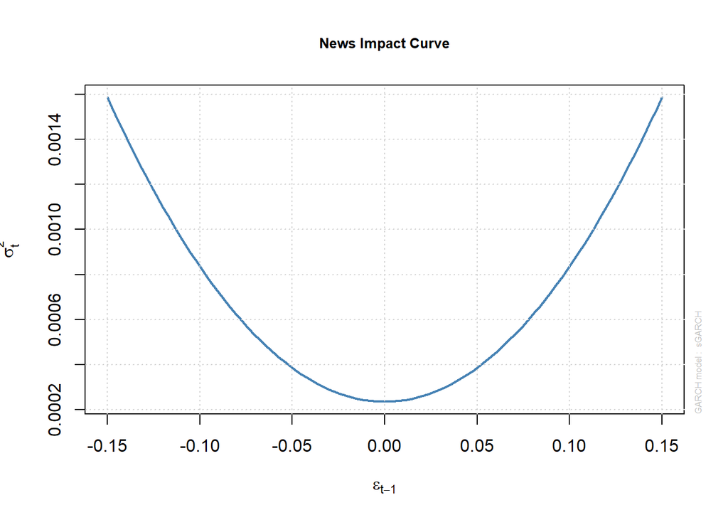

```r
plot_news_impact_curve(arma00garch21)
```

The curve shows that lagged shock value impacts current conditional variance equally. For returns we would like to see stronger volatility reaction on negative shocks.

### Standardized residuals

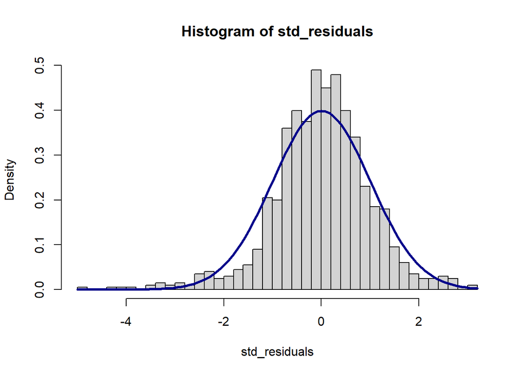

```r
plot_r_std_density(arma00garch21)
```

```r
std_residuals = (arma00garch21@fit$residuals
                 - mean(arma00garch21@fit$residuals)) / arma00garch21@fit$sigma

print(basicStats(std_residuals))
```

```
##             std_residuals
## nobs          1001.000000
## NAs              0.000000
## Minimum         -4.814840
## Maximum          3.169288
## 1. Quartile     -0.539808
## 3. Quartile      0.598667
## Mean             0.004577
## Median           0.024089
## Sum              4.581446
## SE Mean          0.031620
## LCL Mean        -0.057471
## UCL Mean         0.066625
## Variance         1.000796
## Stdev            1.000398
## Skewness        -0.491385
## Kurtosis         1.987838
```

```r
print(jarque.bera.test(std_residuals))
```

```
##
##  Jarque Bera Test
##
## data:  std_residuals
## X-squared = 206.87, df = 2, p-value < 2.2e-16
```

## ARMA(5,5)-EGARCH(2,1)

Let’s display the statistics of the model again.

```r
arma55egarch21
```

```
##
## *---------------------------------*
## *          GARCH Model Fit        *
## *---------------------------------*
##
## Conditional Variance Dynamics
## -----------------------------------
## GARCH Model  : eGARCH(2,1)
## Mean Model   : ARFIMA(5,0,5)
## Distribution : norm
##
## Optimal Parameters
## ------------------------------------
##         Estimate  Std. Error     t value Pr(>|t|)
## mu      0.001299    0.000041     31.8566 0.000000
## ar1    -1.239032    0.000664  -1866.2766 0.000000
## ar2    -1.181832    0.000658  -1795.1099 0.000000
## ar3    -1.096081    0.000537  -2039.7457 0.000000
## ar4    -0.574753    0.000263  -2186.3007 0.000000
## ar5     0.178535    0.000476    375.4515 0.000000
## ma1     1.233690    0.000014  88113.3011 0.000000
## ma2     1.254579    0.000090  13876.0752 0.000000
## ma3     1.191495    0.000011 103965.3869 0.000000
## ma4     0.650839    0.000149   4358.2907 0.000000
## ma5    -0.161400    0.000069  -2338.1387 0.000000
## omega  -0.437674    0.064988     -6.7347 0.000000
## alpha1 -0.142634    0.020789     -6.8611 0.000000
## alpha2  0.093977    0.003501     26.8444 0.000000
## beta1   0.946881    0.007410    127.7791 0.000000
## gamma1  0.099999    0.008728     11.4571 0.000000
## gamma2  0.119600    0.031760      3.7657 0.000166
##
## Robust Standard Errors:
##         Estimate  Std. Error    t value Pr(>|t|)
## mu      0.001299    0.000032    40.0030 0.000000
## ar1    -1.239032    0.000596 -2079.3173 0.000000
## ar2    -1.181832    0.000959 -1232.6348 0.000000
## ar3    -1.096081    0.000344 -3184.4283 0.000000
## ar4    -0.574753    0.000414 -1389.0204 0.000000
## ar5     0.178535    0.000499   357.9871 0.000000
```

[output cut: 76 more lines]

```
## Negative Sign Bias  1.2083 0.2272
## Positive Sign Bias  0.5064 0.6127
## Joint Effect        1.7457 0.6268
##
##
## Adjusted Pearson Goodness-of-Fit Test:
## ------------------------------------
##   group statistic p-value(g-1)
## 1    20     45.61   0.00056205
## 2    30     69.38   0.00003685
## 3    40     70.21   0.00159386
## 4    50     78.57   0.00464709
##
##
## Elapsed time : 3.496656
```

### Parameters Discussion

- Each parameter is significant (even highly significant).
- alpha values indicate presence of lagged error terms influence, albeit a mild one, because absolute values are somewhat small.
- On the contrary, beta is very large, indicating strong influence of lagged volatility.
- Regarding the asymmetry of reaction, according to the rugarch specification, the sign effect is captured by alpha. The alpha1 is negative and larger in absolute value than alpha2, therefore we conclude that negative shocks will have more impact on volatility than positive, at least for the first lag.
- gamma values are positive. According to the rugarch specification, it indicates the influence of difference $|z_t|-E|z_t|$ (absolute standardized residuals). It seems, in this context it is desired for gamma to be positive (as opposed to the gamma from lecture 10), because the larger the difference is, the greater the shock is in comparison to average, independently of sign.

### Nyblom stability test

Joint Statistic is 2.1538 (Critical Value at 5%: 3.95) and all individual statistics are below their respective critical values, indicating parameter stability.

### Ljung - Box and LM tests

No autocorrelation between residuals.

### Goodness-of-Fit Test

The goodness-of-fit test indicates bad fit quality: we reject the null.

### Sign Bias Test

The test fails to reject the null of no bias, and we have achieved the symmetry in reaction to both negative and positive shocks, which is good.

### News Impact Curve

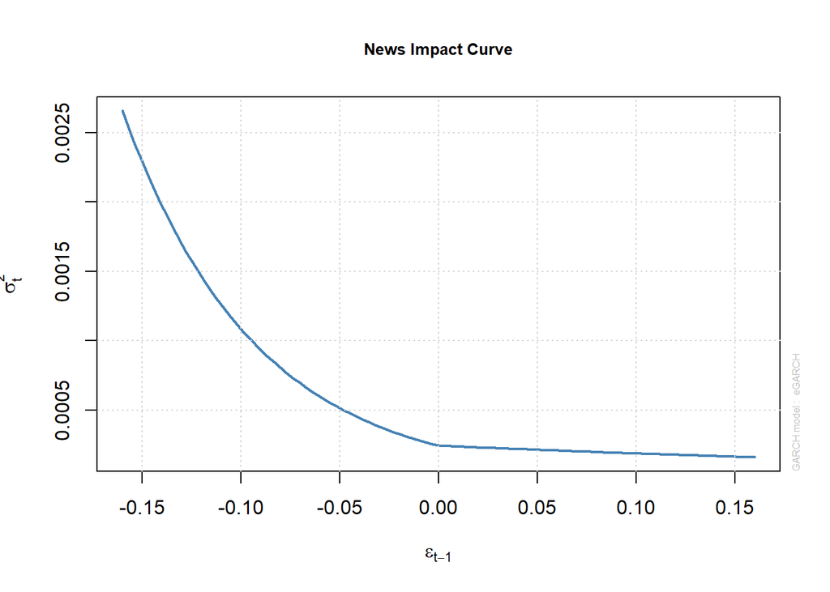

```r
plot_news_impact_curve(arma55egarch21)
```

As expected from the eGARCH model, negative shocks produce more influence on volatility than positive. This is the desired outcome for returns.

### Standardized residuals

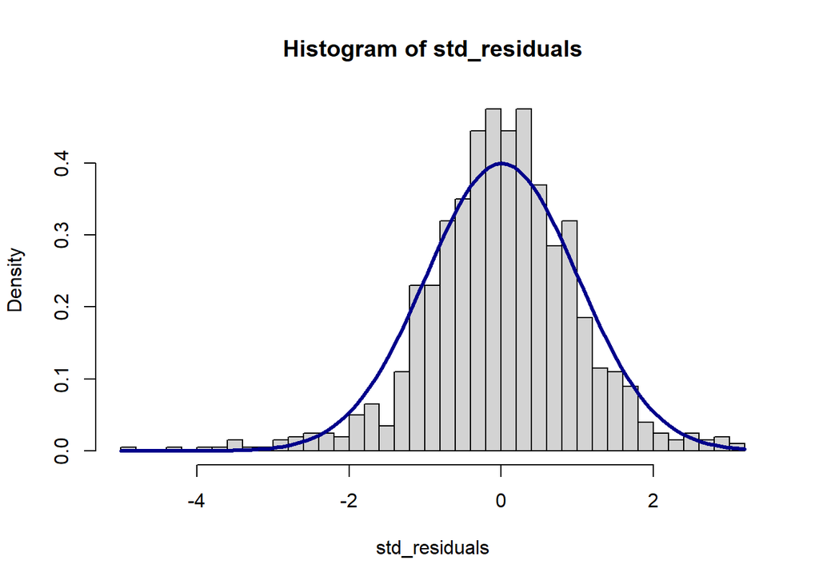

```r
plot_r_std_density(arma55egarch21)
```

```r
std_residuals = (arma55egarch21@fit$residuals
                 - mean(arma55egarch21@fit$residuals)) / arma55egarch21@fit$sigma

print(basicStats(std_residuals))
```

```
##             std_residuals
## nobs          1001.000000
## NAs              0.000000
## Minimum         -4.895212
## Maximum          3.109959
## 1. Quartile     -0.545354
## 3. Quartile      0.602257
## Mean             0.007109
## Median           0.030112
## Sum              7.116169
## SE Mean          0.031570
## LCL Mean        -0.054842
## UCL Mean         0.069060
## Variance         0.997659
## Stdev            0.998829
## Skewness        -0.407183
## Kurtosis         1.846018
```

```r
print(jarque.bera.test(std_residuals))
```

```
##
##  Jarque Bera Test
##
## data:  std_residuals
## X-squared = 171.37, df = 2, p-value < 2.2e-16
```

# Value-at-Risk

```r
plot_var = function(dates, returns, vars, ylims){
  if(missing(ylims))
  {
    ylims = c(-0.2, 0.1)
  }

  plot(dates, returns,
   col = "red", lwd = 1, type = 'l',
   ylim = ylims)
  abline(h = 0, lty = 2)
  lines(dates, vars, type = 'l', col = "green")
}

var_losses = function(returns, vars){
  sum(returns < vars) / length(vars)
}
```

Value-at-Risk is assumed at confidence level 1%. The empirical quantile is:

```r
get_var_quantile = function(returns, q_value) {
  rstd <- (returns - mean(returns))/sd(returns)
  q <-  quantile(rstd, q_value)
  return(q)
}

threshold = 0.01
var_q <- get_var_quantile(insample_r$r, threshold)
var_q
```

```
##        1%
## -2.764884
```

## In-sample

### GARCH

Calculate VAR from chosen model.

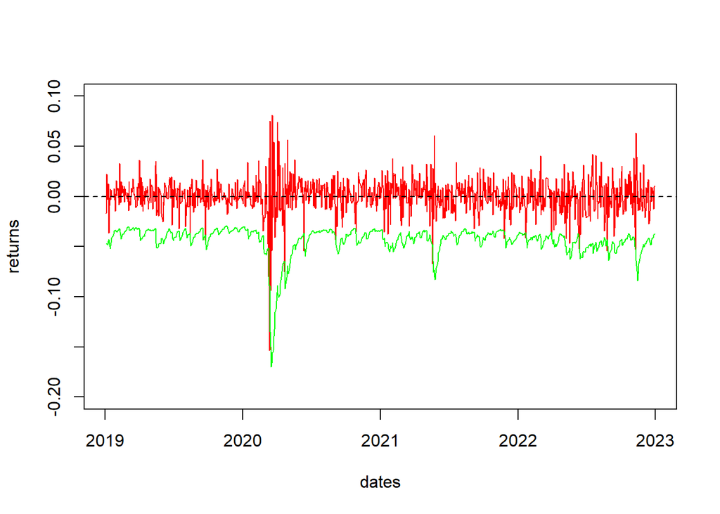

```r
insample_garch <- chosen_garch(insample_r$r)
vars <- var_q * insample_garch@fit$sigma

plot_var(insample_r$Date, insample_r$r, vars)
```

```r
var_losses(insample_r$r, vars)
```

```
## [1] 0.01398601
```

Worse than expected. Let’s test with VaR 5%.

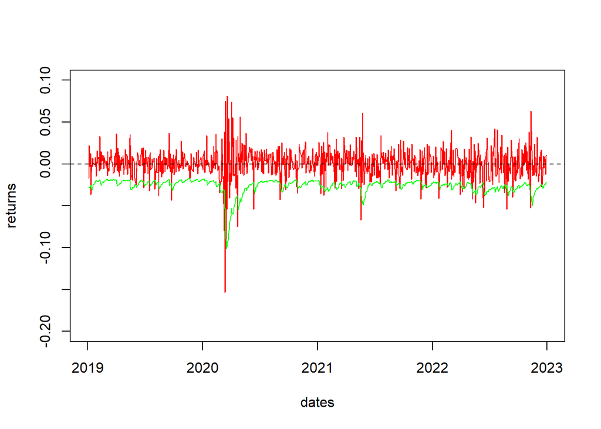

```r
vars <- get_var_quantile(insample_r$r, 0.05) * insample_garch@fit$sigma
plot_var(insample_r$Date, insample_r$r, vars)
```

```r
var_losses(insample_r$r, vars)
```

```
## [1] 0.04495504
```

VaR 5% breaches are in expected range.

### EGARCH

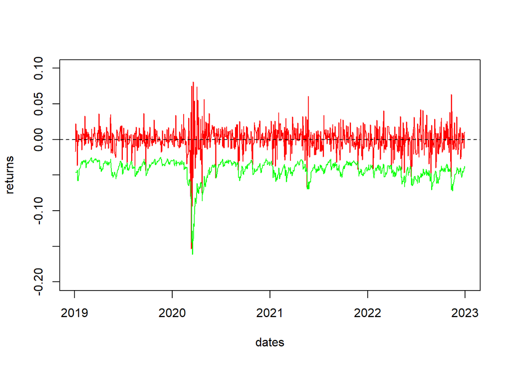

```r
insample_egarch <- chosen_mod_garch(insample_r$r)
vars <- var_q * insample_egarch@fit$sigma

plot_var(insample_r$Date, insample_r$r, vars)
```

```r
var_losses(insample_r$r, vars)
```

```
## [1] 0.01198801
```

Better than simple GARCH, but still above 1% level.

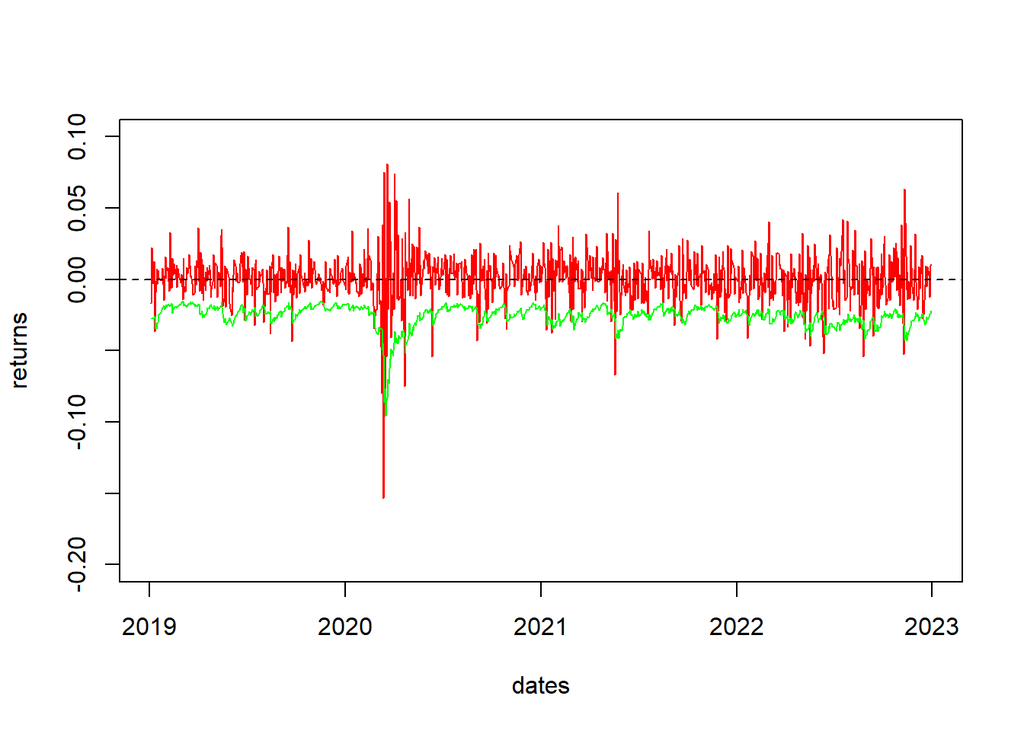

```r
vars <- get_var_quantile(insample_r$r, 0.05) * insample_egarch@fit$sigma
plot_var(insample_r$Date, insample_r$r, vars)
```

```r
var_losses(insample_r$r, vars)
```

```
## [1] 0.04695305
```

Here the results are OK.

For the sake of comparison, let’s try simpler model ARMA(0,0)-EGARCH(2,1).

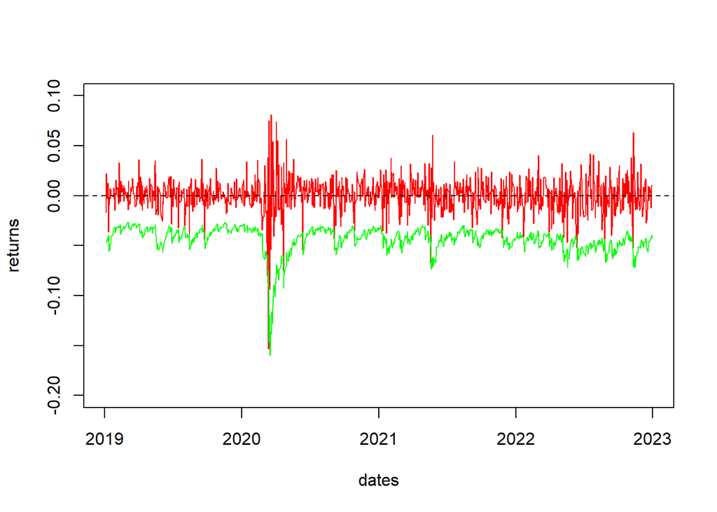

```r
vars <- var_q * arma00egarch21@fit$sigma

plot_var(insample_r$Date, insample_r$r, vars)
```

```r
var_losses(insample_r$r, vars)
```

```
## [1] 0.00999001
```

Interestingly, it is even better on in-sample data, being exactly on 1% breach level.

It seems, for VaR purposes ARCH(0,0)-EGARCH(2,1) may actually be better. But let us stick to the already chosen models.

## Out-of-sample

```r
joined_returns$obs <- 1:length(joined_returns$r)
outofsample_r <- joined_returns %>% filter(Date >= as.Date('2023-01-01'))

start <- (joined_returns %>%
            filter(Date >= as.Date("2023-01-01")) %>%
            filter(row_number() == 1))$obs
finish  <- (joined_returns %>% filter(row_number() == n()))$obs

forecast_rolling_var = function(q_value, garch_func) {
  vars <- rep(NA, times = finish - start + 1)

  n_cores = detectCores() - 1
  cluster <- makeCluster(n_cores)
  registerDoParallel(cluster)

  vars <- foreach(new_idx=start:finish,
                  .export=c("joined_returns", "get_var_quantile", "fit_garch",
                            "ugarchspec", "ugarchfit", "ugarchforecast")) %dopar% {
     rolling_data <- joined_returns[joined_returns$obs <= new_idx-1, ]
     q <- get_var_quantile(rolling_data$r, q_value)

     rolling_garch <- garch_func(rolling_data$r)
     forecast <- ugarchforecast(rolling_garch, n.ahead = 1)
     sigma_for <- forecast@forecast$sigmaFor[1, 1]

     q * sigma_for
  }

  stopCluster(cluster)

  return(vars)
}
```

### GARCH

```r
vars_garch <- forecast_rolling_var(0.01, chosen_garch)
```

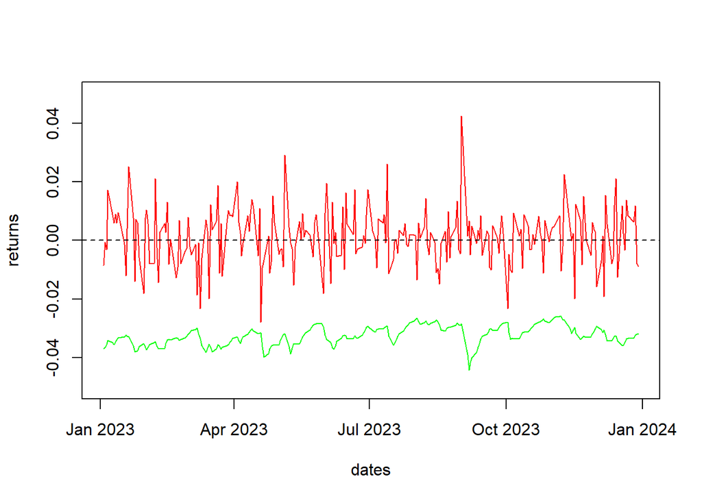

```r
plot_var(outofsample_r$Date, outofsample_r$r, vars_garch, ylims=c(-0.05, 0.05))
```

```r
var_losses(outofsample_r$r, vars_garch)
```

```
## [1] 0
```

There are no return values breaching VaR 1%.

### EGARCH

```r
vars_egarch <- forecast_rolling_var(0.01, chosen_mod_garch)
```

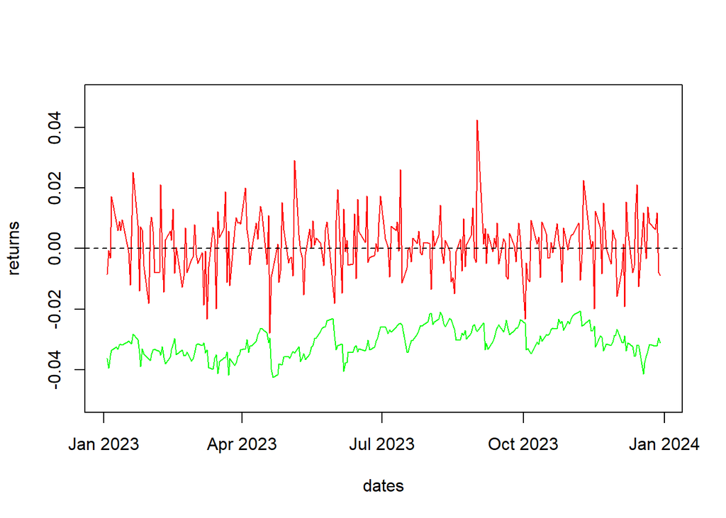

```r
plot_var(outofsample_r$Date, outofsample_r$r, vars_egarch, ylims=c(-0.05, 0.05))
```

```r
var_losses(outofsample_r$r, vars_egarch)
```

```
## [1] 0
```

There are no return values breaching VaR 1%.

# Overall conclusion

The final conclusion is that both standard GARCH and EGARCH both perform well when estimating VaR, with EGARCH being slightly better.